# Gemma LMM Summary

# Dataset: ‘dataset_2-S-2ndLine_bin’ prediction accuracy summary

| drug | 1 | 0 | 1/1 | 1/0 | 0/1 | 0/0 | precission | recall | f1 | accuracy |
| --- | --- | --- | --- | --- | --- | --- | --- | --- | --- | --- |
| OFLO | 10 | 38 | 0.1875 | 0.0208 | 0 | 0.7917 | 1 | 0.9 | 0.9474 | 0.9792 |
| OFLO-nodup | 10 | 38 | 0.2083 | 0.0000 | 0 | 0.7917 | 1 | 1.0 | 1.0000 | 1.0000 |

## ‘OFLO’ Details

**ROC learning curve**

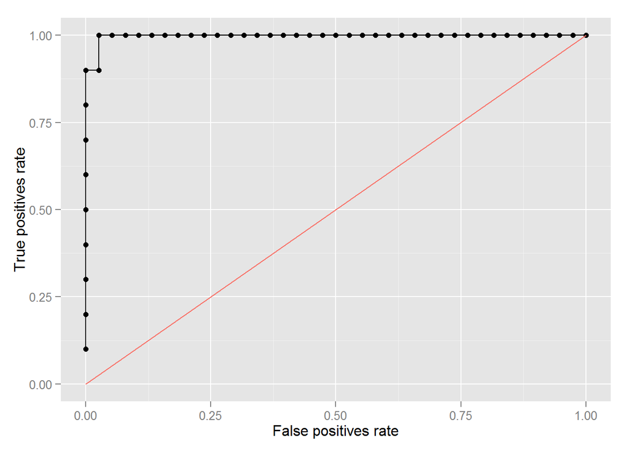

**Manhattan Plot**

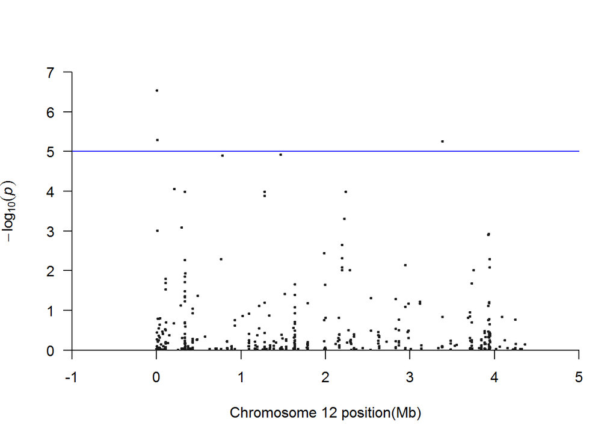

```r
manhattan(test.gwas, cex = .5)
```

**Q-Q Plot**

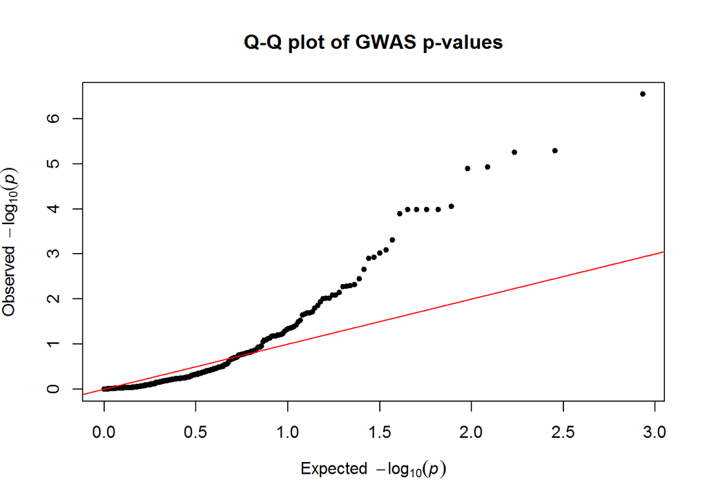

**Significant mutations**

|  | ps | allele1 | allele0 | af | p_lrt | bonferroni | holm | hochberg | fdr | BY |
| --- | --- | --- | --- | --- | --- | --- | --- | --- | --- | --- |
| 8 | 4086 | T | G | 0.250 | 0.0000002884 | 0.0001234 | 0.0001234 | 0.0001234 | 0.0001234 | 0.0008193 |
| 12 | 7570 | T | C | 0.083 | 0.0009734149 | 0.4166216 | 0.4039672 | 0.4039672 | 0.0297587 | 0.1975235 |
| 13 | 7582 | G | A | 0.104 | 0.0000051228 | 0.0021926 | 0.0021874 | 0.0021874 | 0.0007890 | 0.0052368 |
| 354 | 209944 | A | C | 0.042 | 0.0000885886 | 0.0379159 | 0.0374730 | 0.0374730 | 0.0044323 | 0.0294195 |
| 435 | 295731 | C | T | 0.312 | 0.0008122794 | 0.3476556 | 0.3379082 | 0.3379082 | 0.0267427 | 0.1775051 |
| 489 | 333615 | C | G | 0.229 | 0.0001035586 | 0.0443231 | 0.0437016 | 0.0433911 | 0.0044323 | 0.0294195 |
| 490 | 333617 | C | A | 0.229 | 0.0001035585 | 0.0443230 | 0.0437016 | 0.0433911 | 0.0044323 | 0.0294195 |
| 505 | 336050 | G | A | 0.188 | 0.0054122980 | 1.0000000 | 1.0000000 | 0.9996313 | 0.1052938 | 0.6988883 |
| 1034 | 761158 | T | C | 0.396 | 0.0051343590 | 1.0000000 | 1.0000000 | 0.9996313 | 0.1046431 | 0.6945694 |
| 1066 | 781690 | G | A | 0.333 | 0.0000127673 | 0.0054644 | 0.0054133 | 0.0054133 | 0.0010929 | 0.0072540 |
| 1668 | 1276397 | A | G | 0.229 | 0.0001035588 | 0.0443232 | 0.0437016 | 0.0433911 | 0.0044323 | 0.0294195 |
| 1683 | 1276890 | T | C | 0.229 | 0.0001288975 | 0.0551681 | 0.0538792 | 0.0538792 | 0.0050153 | 0.0332890 |
| 1906 | 1468465 | G | A | 0.271 | 0.0000119912 | 0.0051323 | 0.0050963 | 0.0050963 | 0.0010929 | 0.0072540 |
| 2530 | 1982083 | C | G | 0.021 | 0.0036064130 | 1.0000000 | 1.0000000 | 0.9996313 | 0.0857525 | 0.5691827 |
| 2863 | 2196722 | C | G | 0.417 | 0.0082466680 | 1.0000000 | 1.0000000 | 0.9996313 | 0.1421127 | 0.9432740 |
| 2873 | 2196866 | A | G | 0.208 | 0.0095500690 | 1.0000000 | 1.0000000 | 0.9996313 | 0.1494312 | 0.9918505 |
| 2877 | 2196971 | C | A | 0.396 | 0.0047977900 | 1.0000000 | 1.0000000 | 0.9996313 | 0.1046431 | 0.6945694 |
| 2878 | 2196976 | C | G | 0.375 | 0.0022304060 | 0.9546138 | 0.9189273 | 0.9189273 | 0.0561538 | 0.3727209 |
| 2921 | 2220520 | T | G | 0.146 | 0.0004882434 | 0.2089682 | 0.2035975 | 0.2035975 | 0.0174140 | 0.1155856 |
| 2947 | 2241099 | T | C | 0.229 | 0.0001035584 | 0.0443230 | 0.0437016 | 0.0433911 | 0.0044323 | 0.0294195 |
| 3012 | 2289048 | C | A | 0.208 | 0.0095456470 | 1.0000000 | 1.0000000 | 0.9996313 | 0.1494312 | 0.9918505 |
| 3878 | 2944534 | G | C | 0.292 | 0.0071907430 | 1.0000000 | 1.0000000 | 0.9996313 | 0.1338103 | 0.8881671 |
| 4324 | 3382124 | T | C | 0.167 | 0.0000055302 | 0.0023669 | 0.0023559 | 0.0023559 | 0.0007890 | 0.0052368 |
| 4820 | 3754038 | C | A | 0.208 | 0.0097758720 | 1.0000000 | 1.0000000 | 0.9996313 | 0.1494312 | 0.9918505 |
| 5114 | 3927774 | A | G | 0.083 | 0.0012423440 | 0.5317232 | 0.5130881 | 0.5130881 | 0.0332327 | 0.2205823 |
| 5122 | 3931640 | G | C | 0.271 | 0.0011996170 | 0.5134361 | 0.4966414 | 0.4966414 | 0.0332327 | 0.2205823 |
| 5157 | 3943323 | C | A | 0.375 | 0.0050595550 | 1.0000000 | 1.0000000 | 0.9996313 | 0.1046431 | 0.6945694 |
| 5162 | 3943928 | G | A | 0.062 | 0.0083009760 | 1.0000000 | 1.0000000 | 0.9996313 | 0.1421127 | 0.9432740 |

## ‘OFLO-nodup’ Details

**ROC learning curve**

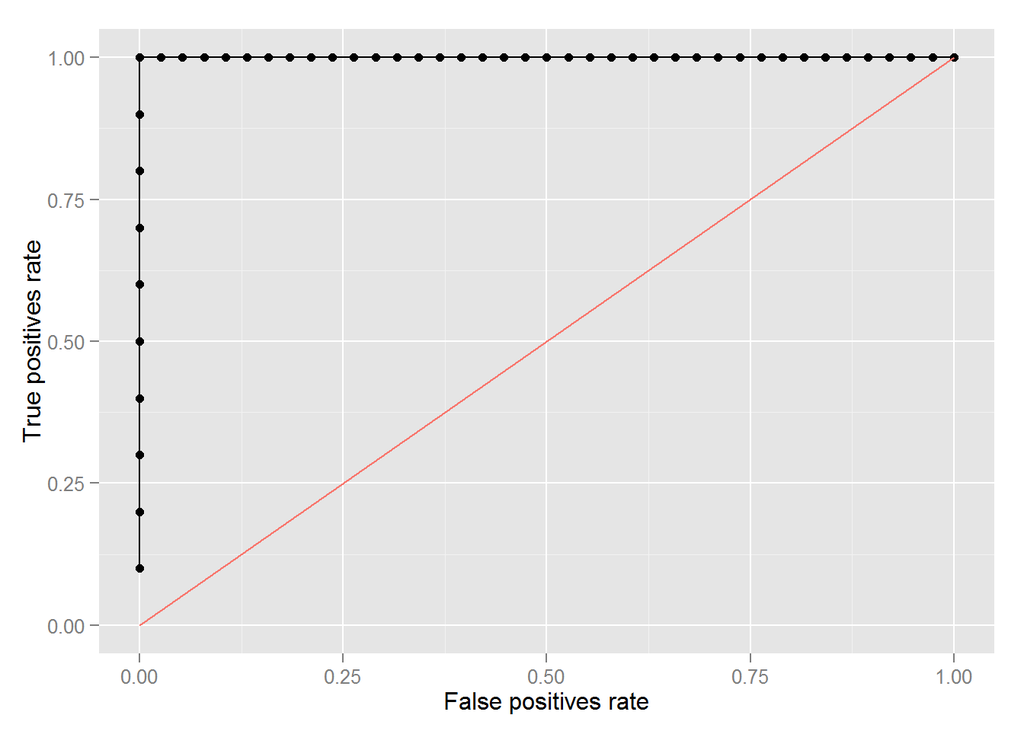

**Manhattan Plot**

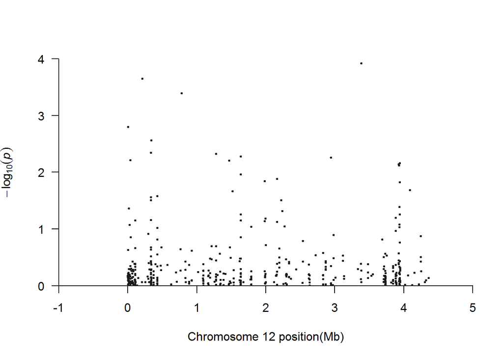

```r
manhattan(test.gwas, cex = .5)
```

**Q-Q Plot**

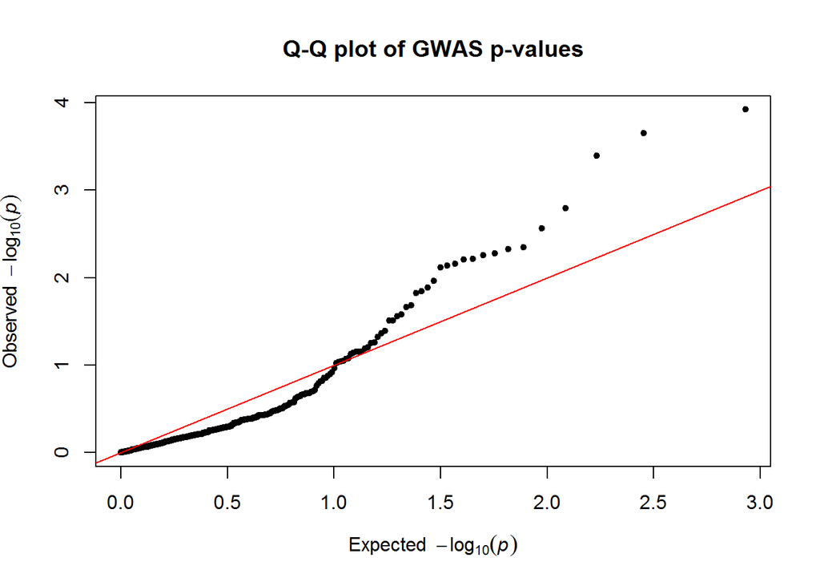

**Significant mutations**

|  | ps | allele1 | allele0 | af | p_lrt | bonferroni | holm | hochberg | fdr | BY |
| --- | --- | --- | --- | --- | --- | --- | --- | --- | --- | --- |
| 8 | 4086 | T | G | 0.250 | 0.0015973 | 0.68045 | 0.67566 | 0.67566 | 0.17011 | 1.0000 |
| 34 | 35978 | A | G | 0.062 | 0.0061464 | 1.00000 | 1.00000 | 0.99887 | 0.23191 | 1.0000 |
| 75 | 209944 | A | C | 0.042 | 0.0002226 | 0.09484 | 0.09461 | 0.09461 | 0.04742 | 0.3145 |
| 88 | 333637 | G | A | 0.125 | 0.0045043 | 1.00000 | 1.00000 | 0.99887 | 0.23191 | 1.0000 |
| 102 | 338322 | A | C | 0.021 | 0.0027321 | 1.00000 | 1.00000 | 0.99887 | 0.23191 | 1.0000 |
| 139 | 781690 | G | A | 0.333 | 0.0004053 | 0.17267 | 0.17186 | 0.17186 | 0.05756 | 0.3818 |
| 180 | 1276890 | T | C | 0.229 | 0.0047213 | 1.00000 | 1.00000 | 0.99887 | 0.23191 | 1.0000 |
| 195 | 1468465 | G | A | 0.271 | 0.0061836 | 1.00000 | 1.00000 | 0.99887 | 0.23191 | 1.0000 |
| 213 | 1636179 | G | C | 0.125 | 0.0052819 | 1.00000 | 1.00000 | 0.99887 | 0.23191 | 1.0000 |
| 310 | 2944779 | C | G | 0.417 | 0.0055016 | 1.00000 | 1.00000 | 0.99887 | 0.23191 | 1.0000 |
| 327 | 3382124 | T | C | 0.167 | 0.0001196 | 0.05096 | 0.05096 | 0.05096 | 0.04742 | 0.3145 |
| 385 | 3927774 | A | G | 0.083 | 0.0072352 | 1.00000 | 1.00000 | 0.99887 | 0.23191 | 1.0000 |
| 388 | 3931640 | G | C | 0.271 | 0.0076215 | 1.00000 | 1.00000 | 0.99887 | 0.23191 | 1.0000 |
| 407 | 3943928 | G | A | 0.062 | 0.0069669 | 1.00000 | 1.00000 | 0.99887 | 0.23191 | 1.0000 |

# Dataset: ‘dataset_3-S-oflo_bin’ prediction accuracy summary

| drug | 1 | 0 | 1/1 | 1/0 | 0/1 | 0/0 | precission | recall | f1 | accuracy |
| --- | --- | --- | --- | --- | --- | --- | --- | --- | --- | --- |
| AMIK | 8 | 46 | 0.1481 | 0 | 0.2593 | 0.5926 | 0.3636 | 1 | 0.5333 | 0.7407 |
| AMIK-nodup | 8 | 46 | 0.1481 | 0 | 0.4815 | 0.3704 | 0.2353 | 1 | 0.3810 | 0.5185 |
| CAPR | 10 | 40 | 0.2000 | 0 | 0.7600 | 0.0400 | 0.2083 | 1 | 0.3448 | 0.2400 |
| CAPR-nodup | 10 | 40 | 0.2000 | 0 | 0.8000 | 0.0000 | 0.2000 | 1 | 0.3333 | 0.2000 |

## ‘AMIK’ Details

**ROC learning curve**

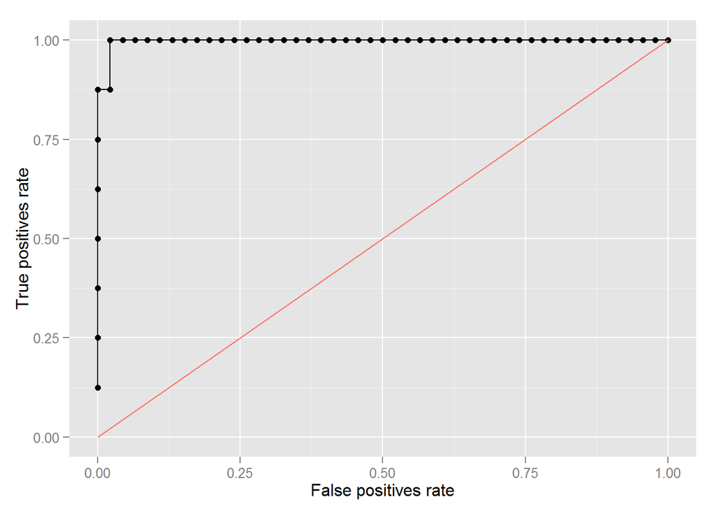

**Manhattan Plot**

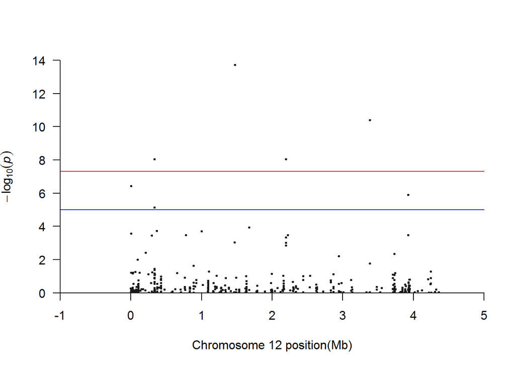

```r
manhattan(test.gwas, cex = .5)
```

**Q-Q Plot**

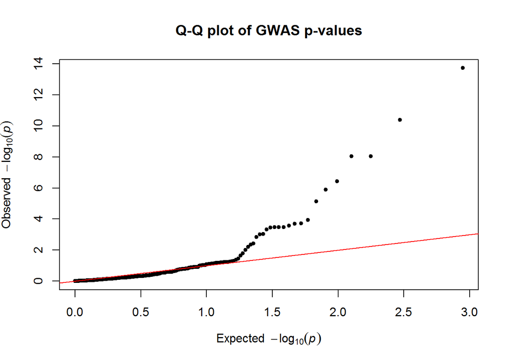

**Significant mutations**

|  | ps | allele1 | allele0 | af | p_lrt | bonferroni | holm | hochberg | fdr | BY |
| --- | --- | --- | --- | --- | --- | --- | --- | --- | --- | --- |
| 9 | 4086 | T | G | 0.204 | 0.00000038052020000 | 0.000168950968800 | 0.000167428888000 | 0.000167428888000 | 0.000033790193760 | 0.00022552135999 |
| 11 | 6579 | T | C | 0.019 | 0.00026438750000000 | 0.117388050000000 | 0.114744175000000 | 0.114744175000000 | 0.010271635120000 | 0.06855459717090 |
| 360 | 209944 | A | C | 0.037 | 0.00383913000000000 | 1.000000000000000 | 1.000000000000000 | 0.999282700000000 | 0.085228686000000 | 0.56883039242294 |
| 441 | 295731 | C | T | 0.333 | 0.00034701470000000 | 0.154074526800000 | 0.149216321000000 | 0.149216321000000 | 0.010271635120000 | 0.06855459717090 |
| 496 | 333624 | G | T | 0.185 | 0.00000000883098700 | 0.000003920958228 | 0.000003903295812 | 0.000003894465267 | 0.000000980239557 | 0.00000654228146 |
| 498 | 333632 | T | A | 0.167 | 0.00000721669400000 | 0.003204212136000 | 0.003160911972000 | 0.003160911972000 | 0.000457744590857 | 0.00305506335328 |
| 604 | 365328 | C | T | 0.093 | 0.00019095720000000 | 0.084784996800000 | 0.083257339200000 | 0.083257339200000 | 0.008784326880000 | 0.05862805518698 |
| 1086 | 781690 | G | A | 0.259 | 0.00033532690000000 | 0.148885143600000 | 0.144525893900000 | 0.144525893900000 | 0.010271635120000 | 0.06855459717090 |
| 1353 | 1001128 | T | C | 0.056 | 0.00019784520000000 | 0.087843268800000 | 0.086062662000000 | 0.086062662000000 | 0.008784326880000 | 0.05862805518698 |
| 1939 | 1468465 | G | A | 0.204 | 0.00092414780000000 | 0.410321623200000 | 0.395535258400000 | 0.395535258400000 | 0.023506479866667 | 0.15688614707773 |
| 1945 | 1473252 | G | A | 0.111 | 0.00000000000001884 | 0.000000000008365 | 0.000000000008365 | 0.000000000008365 | 0.000000000008365 | 0.00000000005583 |
| 2221 | 1673438 | C | T | 0.185 | 0.00011324130000000 | 0.050279137200000 | 0.049486448100000 | 0.049486448100000 | 0.006284892150000 | 0.04194641306591 |
| 2917 | 2196722 | C | G | 0.426 | 0.00142505100000000 | 0.632722644000000 | 0.607071726000000 | 0.607071726000000 | 0.033301191789474 | 0.22225767969435 |
| 2929 | 2196889 | G | A | 0.185 | 0.00000000883098600 | 0.000003920957784 | 0.000003903295812 | 0.000003894465267 | 0.000000980239557 | 0.00000654228146 |
| 2931 | 2196971 | C | A | 0.407 | 0.00095296540000000 | 0.423116637600000 | 0.406916225800000 | 0.406916225800000 | 0.023506479866667 | 0.15688614707773 |
| 2932 | 2196976 | C | G | 0.389 | 0.00046898280000000 | 0.208228363200000 | 0.201193621200000 | 0.201193621200000 | 0.013014272700000 | 0.08685941546770 |
| 2974 | 2220520 | T | G | 0.093 | 0.00033201180000000 | 0.147413239200000 | 0.143761109400000 | 0.143431387200000 | 0.010271635120000 | 0.06855459717090 |
| 3945 | 2944534 | G | C | 0.296 | 0.00623606300000000 | 1.000000000000000 | 1.000000000000000 | 0.999282700000000 | 0.125855089636364 | 0.83997775146126 |
| 4396 | 3382124 | T | C | 0.167 | 0.00000000004056536 | 0.000000018011020 | 0.000000017970454 | 0.000000017970454 | 0.000000009005510 | 0.00000006010427 |
| 4758 | 3730787 | A | G | 0.296 | 0.00455005100000000 | 1.000000000000000 | 1.000000000000000 | 0.999282700000000 | 0.096201078285714 | 0.64206195919497 |
| 5187 | 3927774 | A | G | 0.074 | 0.00000126907000000 | 0.000563467080000 | 0.000557121730000 | 0.000557121730000 | 0.000093911180000 | 0.00062677879807 |
| 5188 | 3927784 | A | T | 0.093 | 0.00033201710000000 | 0.147415592400000 | 0.143761109400000 | 0.143431387200000 | 0.010271635120000 | 0.06855459717090 |

## ‘AMIK-nodup’ Details

**ROC learning curve**

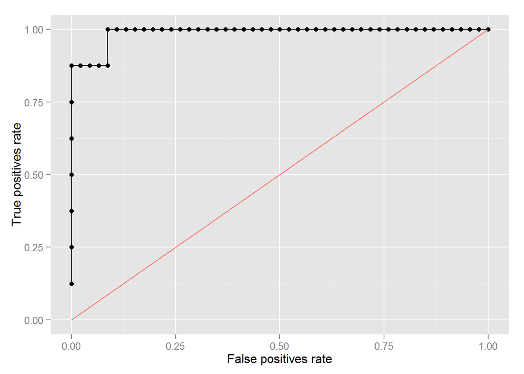

**Manhattan Plot**

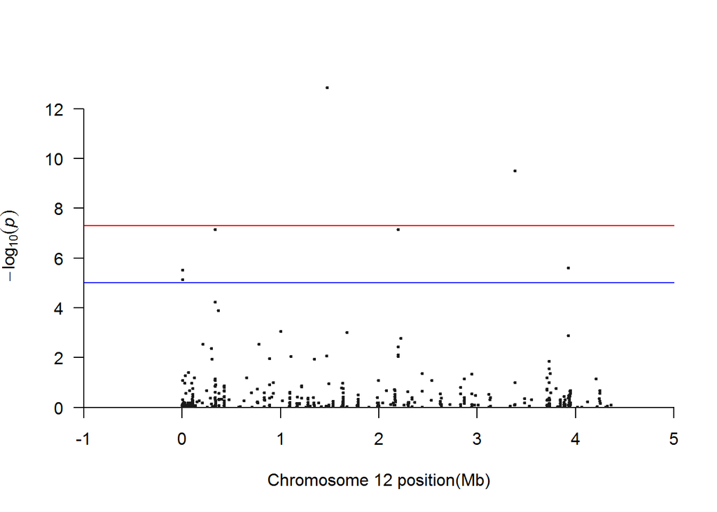

```r
manhattan(test.gwas, cex = .5)
```

**Q-Q Plot**

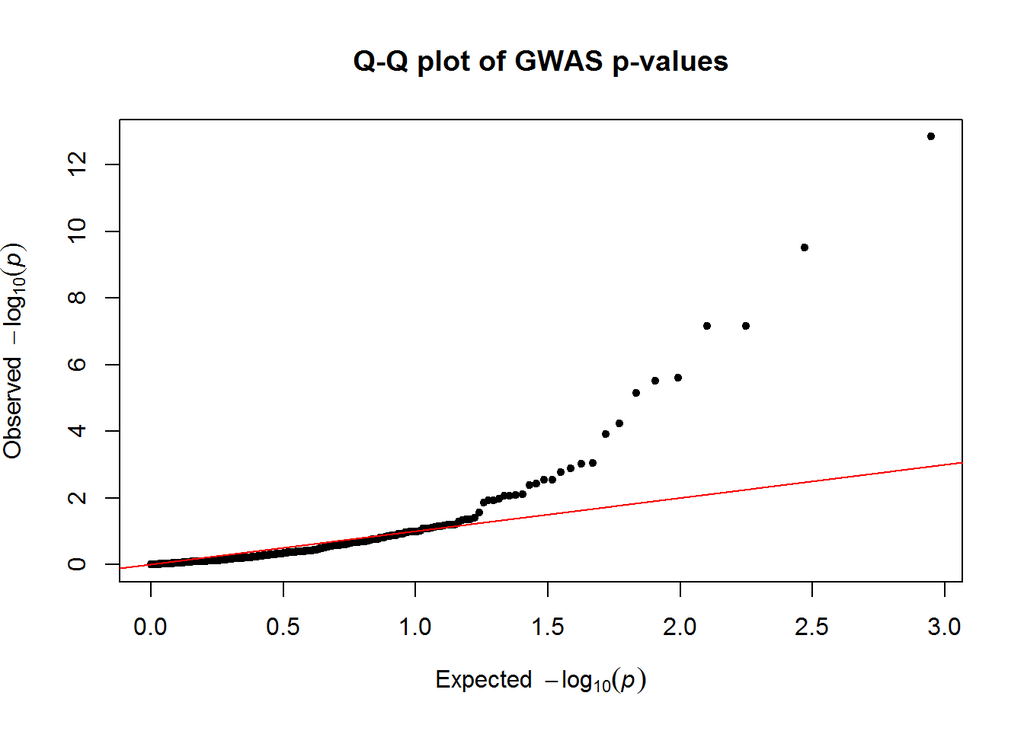

**Significant mutations**

|  | ps | allele1 | allele0 | af | p_lrt | bonferroni | holm | hochberg | fdr | BY |
| --- | --- | --- | --- | --- | --- | --- | --- | --- | --- | --- |
| 9 | 4086 | T | G | 0.204 | 0.0000030643550000 | 0.00136057362000 | 0.00134525184500 | 0.00134525184500 | 0.00022676227000 | 0.0015134490168 |
| 11 | 6579 | T | C | 0.019 | 0.0000072420040000 | 0.00321544977600 | 0.00317199775200 | 0.00317199775200 | 0.00045934996800 | 0.0030657779067 |
| 79 | 209944 | A | C | 0.037 | 0.0029260450000000 | 1.00000000000000 | 1.00000000000000 | 0.99970720000000 | 0.08689085920000 | 0.5799240121654 |
| 84 | 295731 | C | T | 0.333 | 0.0041664920000000 | 1.00000000000000 | 1.00000000000000 | 0.99970720000000 | 0.10881896752941 | 0.7262758457031 |
| 87 | 333624 | G | T | 0.185 | 0.0000000698780600 | 0.00003102585864 | 0.00003088610252 | 0.00003081625974 | 0.00000775647354 | 0.0000517679914 |
| 88 | 333632 | T | A | 0.167 | 0.0000594505300000 | 0.02639603532000 | 0.02597988161000 | 0.02597988161000 | 0.00329950441500 | 0.0220214399549 |
| 115 | 365328 | C | T | 0.093 | 0.0001254383000000 | 0.05569460520000 | 0.05469109880000 | 0.05469109880000 | 0.00618828946667 | 0.0413016707280 |
| 149 | 781690 | G | A | 0.259 | 0.0029355020000000 | 1.00000000000000 | 1.00000000000000 | 0.99970720000000 | 0.08689085920000 | 0.5799240121654 |
| 164 | 1001128 | T | C | 0.056 | 0.0008859698000000 | 0.39337059120000 | 0.38539686300000 | 0.38539686300000 | 0.03908510203636 | 0.2608604564106 |
| 178 | 1104278 | C | T | 0.019 | 0.0087675150000000 | 1.00000000000000 | 1.00000000000000 | 0.99970720000000 | 0.18850897428571 | 1.0000000000000 |
| 212 | 1468465 | G | A | 0.204 | 0.0083406150000000 | 1.00000000000000 | 1.00000000000000 | 0.99970720000000 | 0.18850897428571 | 1.0000000000000 |
| 213 | 1473252 | G | A | 0.111 | 0.0000000000001451 | 0.00000000006445 | 0.00000000006445 | 0.00000000006445 | 0.00000000006445 | 0.0000000004301 |
| 248 | 1673438 | C | T | 0.185 | 0.0009683246000000 | 0.42993612240000 | 0.42025287640000 | 0.42025287640000 | 0.03908510203636 | 0.2608604564106 |
| 289 | 2196722 | C | G | 0.426 | 0.0089159650000000 | 1.00000000000000 | 1.00000000000000 | 0.99970720000000 | 0.18850897428571 | 1.0000000000000 |
| 290 | 2196889 | G | A | 0.185 | 0.0000000698781400 | 0.00003102589416 | 0.00003088610252 | 0.00003081625974 | 0.00000775647354 | 0.0000517679914 |
| 291 | 2196971 | C | A | 0.407 | 0.0077283360000000 | 1.00000000000000 | 1.00000000000000 | 0.99970720000000 | 0.18850897428571 | 1.0000000000000 |
| 292 | 2196976 | C | G | 0.389 | 0.0037532990000000 | 1.00000000000000 | 1.00000000000000 | 0.99970720000000 | 0.10415404725000 | 0.6951413937046 |
| 293 | 2220520 | T | G | 0.093 | 0.0016963560000000 | 0.75318206400000 | 0.73282579200000 | 0.73282579200000 | 0.05793708184615 | 0.3866816977841 |
| 346 | 3382124 | T | C | 0.167 | 0.0000000003162640 | 0.00000014042122 | 0.00000014010495 | 0.00000014010495 | 0.00000007021061 | 0.0000004685972 |
| 405 | 3927774 | A | G | 0.074 | 0.0000024840190000 | 0.00110290443600 | 0.00109296836000 | 0.00109296836000 | 0.00022058088720 | 0.0014721934423 |
| 406 | 3927784 | A | T | 0.093 | 0.0013315490000000 | 0.59120775600000 | 0.57656071700000 | 0.57656071700000 | 0.04926731300000 | 0.3288182219237 |

## ‘CAPR’ Details

**ROC learning curve**

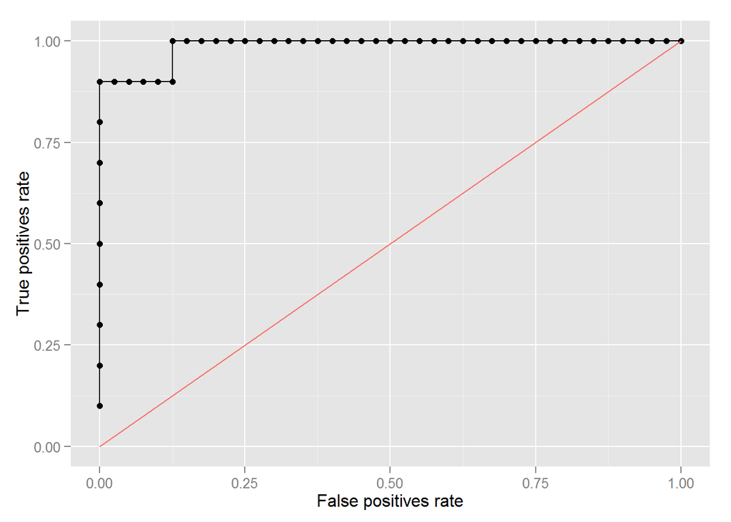

**Manhattan Plot**

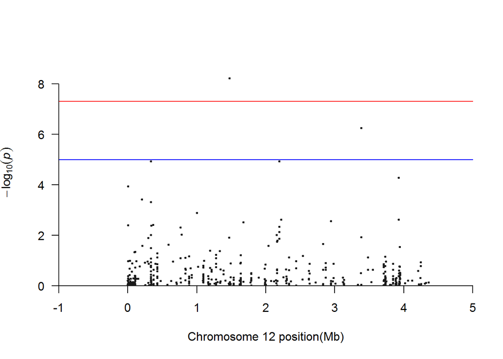

```r
manhattan(test.gwas, cex = .5)
```

**Q-Q Plot**

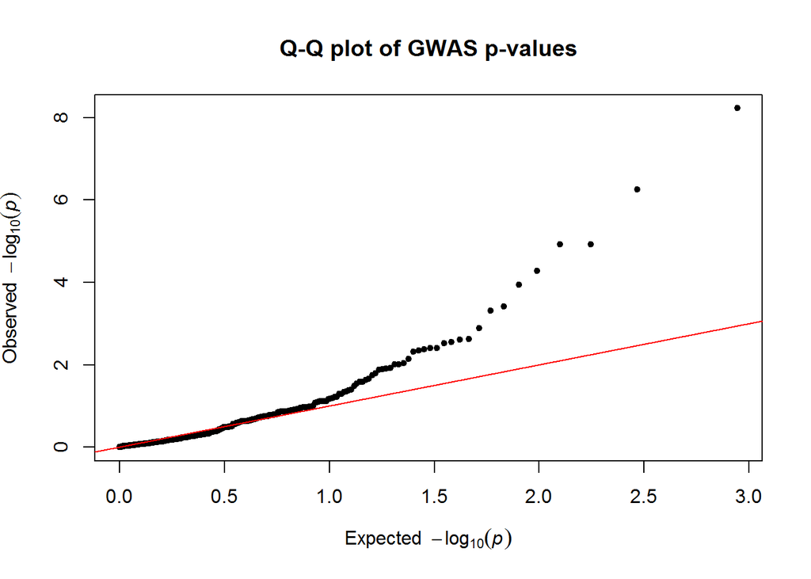

**Significant mutations**

|  | ps | allele1 | allele0 | af | p_lrt | bonferroni | holm | hochberg | fdr | BY |
| --- | --- | --- | --- | --- | --- | --- | --- | --- | --- | --- |
| 9 | 4086 | T | G | 0.22 | 0.000114804200 | 0.050513848 | 0.049939827 | 0.049939827 | 0.008418975 | 0.05611353 |
| 11 | 6579 | T | C | 0.02 | 0.003953752000 | 1.000000000 | 1.000000000 | 0.996769600 | 0.114539398 | 0.76341955 |
| 301 | 202369 | C | G | 0.04 | 0.000383934100 | 0.168931004 | 0.166627399 | 0.166627399 | 0.024133001 | 0.16084950 |
| 443 | 333624 | G | T | 0.20 | 0.000011809300 | 0.005196092 | 0.005172469 | 0.005160664 | 0.001299023 | 0.00865815 |
| 445 | 333632 | T | A | 0.18 | 0.000484462400 | 0.213163456 | 0.209772219 | 0.209772219 | 0.026645432 | 0.17759517 |
| 455 | 335971 | G | A | 0.24 | 0.009713050000 | 1.000000000 | 1.000000000 | 0.996769600 | 0.197066580 | 1.00000000 |
| 502 | 338618 | G | C | 0.34 | 0.004165069000 | 1.000000000 | 1.000000000 | 0.996769600 | 0.114539398 | 0.76341955 |
| 547 | 365328 | C | T | 0.10 | 0.003927725000 | 1.000000000 | 1.000000000 | 0.996769600 | 0.114539398 | 0.76341955 |
| 944 | 761158 | T | C | 0.42 | 0.004897671000 | 1.000000000 | 1.000000000 | 0.996769600 | 0.119720847 | 0.79795457 |
| 975 | 781690 | G | A | 0.28 | 0.009265873000 | 1.000000000 | 1.000000000 | 0.996769600 | 0.197066580 | 1.00000000 |
| 1207 | 1001128 | T | C | 0.06 | 0.001276178000 | 0.561518320 | 0.551308896 | 0.551308896 | 0.062390924 | 0.41584339 |
| 1721 | 1473252 | G | A | 0.12 | 0.000000005951 | 0.000002618 | 0.000002618 | 0.000002618 | 0.000002618 | 0.00001745 |
| 1968 | 1673438 | C | T | 0.20 | 0.002992670000 | 1.000000000 | 1.000000000 | 0.996769600 | 0.101290369 | 0.67511311 |
| 2483 | 2155175 | C | G | 0.46 | 0.009853329000 | 1.000000000 | 1.000000000 | 0.996769600 | 0.197066580 | 1.00000000 |
| 2588 | 2196889 | G | A | 0.20 | 0.000011809290 | 0.005196088 | 0.005172469 | 0.005160664 | 0.001299023 | 0.00865815 |
| 2590 | 2196971 | C | A | 0.42 | 0.007356243000 | 1.000000000 | 1.000000000 | 0.996769600 | 0.170355101 | 1.00000000 |
| 2591 | 2196976 | C | G | 0.40 | 0.004586528000 | 1.000000000 | 1.000000000 | 0.996769600 | 0.118710136 | 0.79121806 |
| 2630 | 2220520 | T | G | 0.10 | 0.002432460000 | 1.000000000 | 1.000000000 | 0.996769600 | 0.097298400 | 0.64850613 |
| 3506 | 2944534 | G | C | 0.30 | 0.002780599000 | 1.000000000 | 1.000000000 | 0.996769600 | 0.101290369 | 0.67511311 |
| 3907 | 3382124 | T | C | 0.18 | 0.000000558122 | 0.000245574 | 0.000245015 | 0.000245015 | 0.000122787 | 0.00081839 |
| 4602 | 3927774 | A | G | 0.08 | 0.000052902140 | 0.023276942 | 0.023065333 | 0.023065333 | 0.004655388 | 0.03102875 |
| 4603 | 3927784 | A | T | 0.10 | 0.002417077000 | 1.000000000 | 1.000000000 | 0.996769600 | 0.097298400 | 0.64850613 |

## ‘CAPR-nodup’ Details

**ROC learning curve**

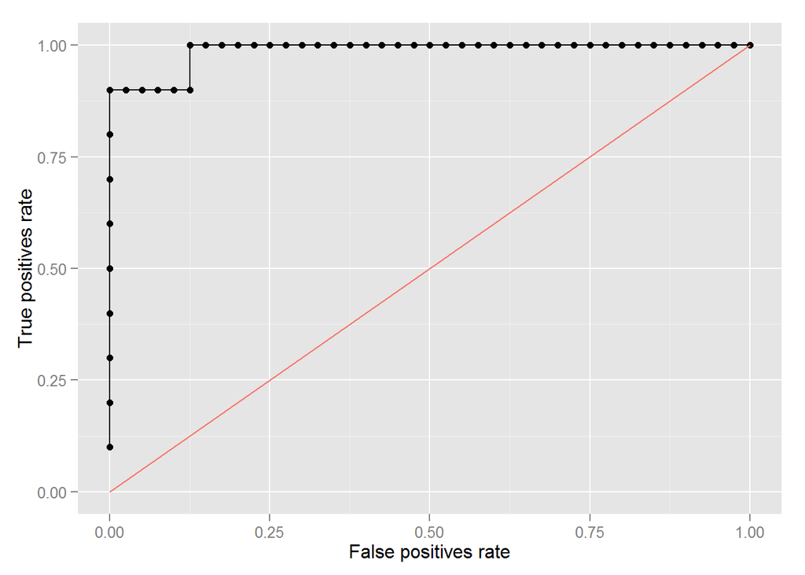

**Manhattan Plot**

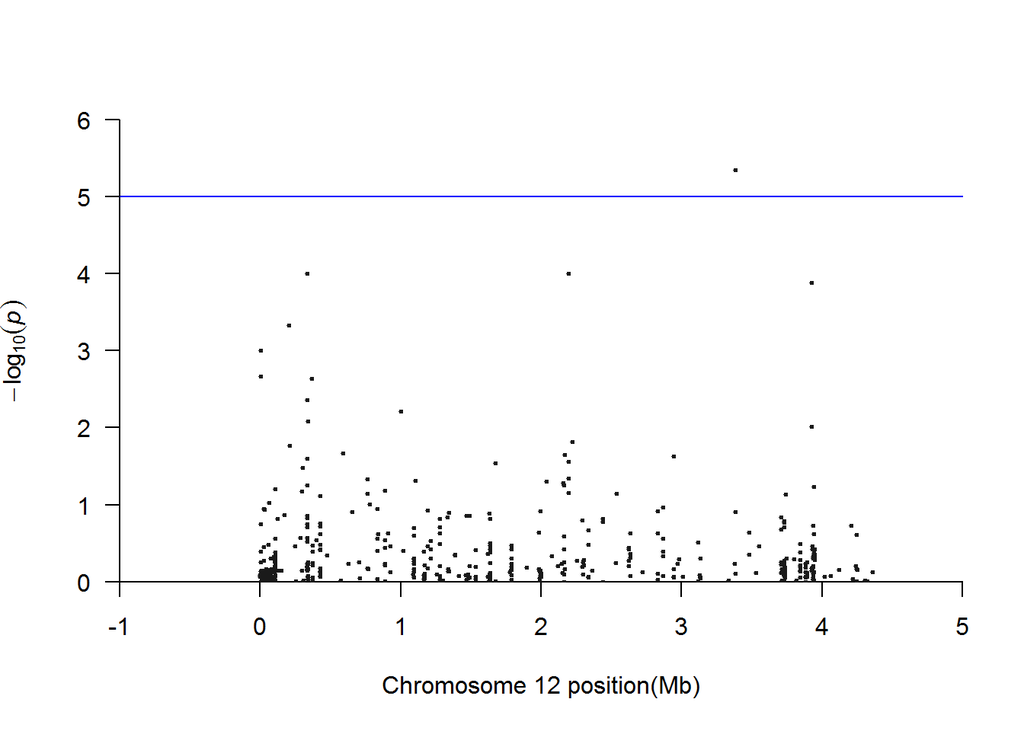

```r
manhattan(test.gwas, cex = .5)
```

**Q-Q Plot**

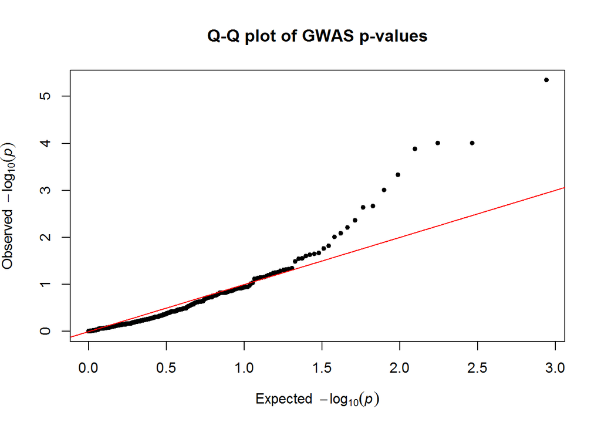

**Significant mutations**

|  | ps | allele1 | allele0 | af | p_lrt | bonferroni | holm | hochberg | fdr | BY |
| --- | --- | --- | --- | --- | --- | --- | --- | --- | --- | --- |
| 9 | 4086 | T | G | 0.22 | 0.000991339 | 0.433215 | 0.428259 | 0.428259 | 0.072203 | 0.48075 |
| 11 | 6579 | T | C | 0.02 | 0.002177429 | 0.951536 | 0.938472 | 0.938472 | 0.127122 | 0.84642 |
| 73 | 202369 | C | G | 0.04 | 0.000464976 | 0.203194 | 0.201335 | 0.201335 | 0.040639 | 0.27059 |
| 82 | 333624 | G | T | 0.20 | 0.000098703 | 0.043133 | 0.043034 | 0.042936 | 0.014191 | 0.09449 |
| 83 | 333632 | T | A | 0.18 | 0.004325062 | 1.000000 | 1.000000 | 0.999640 | 0.210006 | 1.00000 |
| 101 | 338618 | G | C | 0.34 | 0.008167758 | 1.000000 | 1.000000 | 0.999640 | 0.324483 | 1.00000 |
| 110 | 365328 | C | T | 0.10 | 0.002327185 | 1.000000 | 1.000000 | 0.999640 | 0.127122 | 0.84642 |
| 159 | 1001128 | T | C | 0.06 | 0.006180606 | 1.000000 | 1.000000 | 0.999640 | 0.270092 | 1.00000 |
| 284 | 2196889 | G | A | 0.20 | 0.000098703 | 0.043133 | 0.043034 | 0.042936 | 0.014191 | 0.09449 |
| 340 | 3382124 | T | C | 0.18 | 0.000004547 | 0.001987 | 0.001987 | 0.001987 | 0.001987 | 0.01323 |
| 398 | 3927774 | A | G | 0.08 | 0.000129896 | 0.056765 | 0.056375 | 0.056375 | 0.014191 | 0.09449 |
| 399 | 3927784 | A | T | 0.10 | 0.009771318 | 1.000000 | 1.000000 | 0.999640 | 0.355839 | 1.00000 |

# Dataset: ‘dataset_4-S-II_oflo_bin’ prediction accuracy summary

| drug | 1 | 0 | 1/1 | 1/0 | 0/1 | 0/0 | precission | recall | f1 | accuracy |
| --- | --- | --- | --- | --- | --- | --- | --- | --- | --- | --- |
| OFLO | 10 | 38 | 0.1875 | 0.0208 | 0 | 0.7917 | 1 | 0.9 | 0.9474 | 0.9792 |
| OFLO-nodup | 10 | 38 | 0.2083 | 0.0000 | 0 | 0.7917 | 1 | 1.0 | 1.0000 | 1.0000 |

## ‘OFLO’ Details

**ROC learning curve**

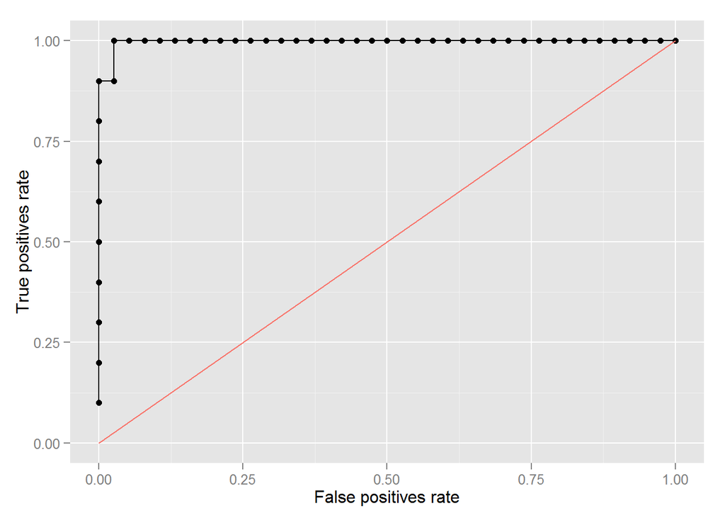

**Manhattan Plot**

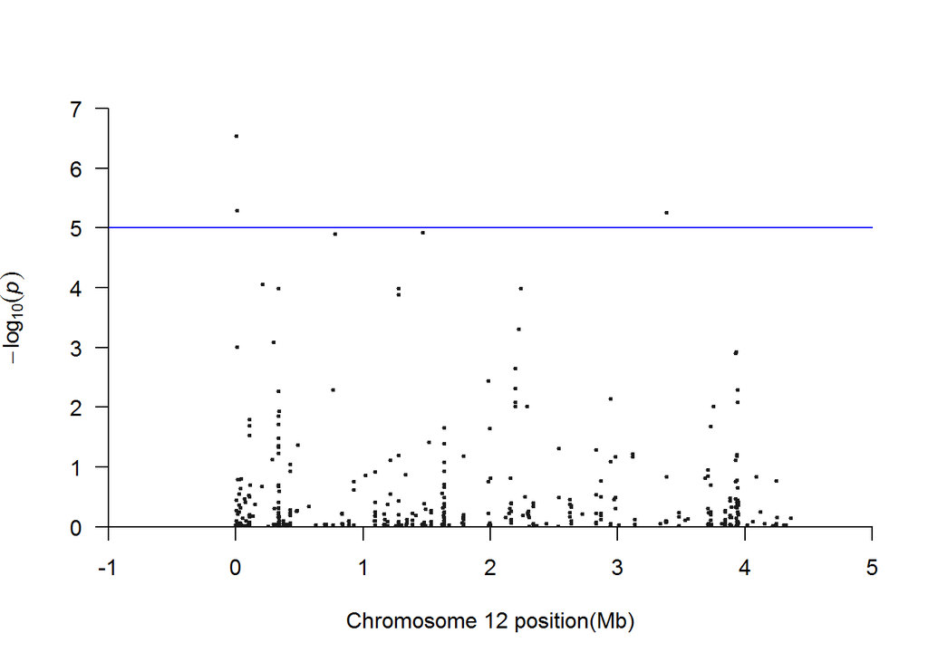

```r
manhattan(test.gwas, cex = .5)
```

**Q-Q Plot**

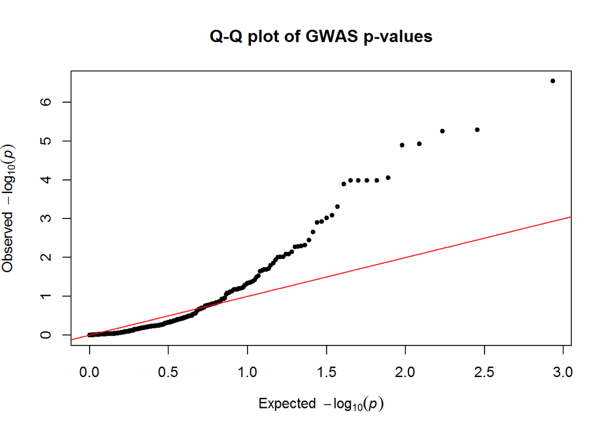

**Significant mutations**

|  | ps | allele1 | allele0 | af | p_lrt | bonferroni | holm | hochberg | fdr | BY |
| --- | --- | --- | --- | --- | --- | --- | --- | --- | --- | --- |
| 8 | 4086 | T | G | 0.250 | 0.0000002884 | 0.0001234 | 0.0001234 | 0.0001234 | 0.0001234 | 0.0008193 |
| 12 | 7570 | T | C | 0.083 | 0.0009734149 | 0.4166216 | 0.4039672 | 0.4039672 | 0.0297587 | 0.1975235 |
| 13 | 7582 | G | A | 0.104 | 0.0000051228 | 0.0021926 | 0.0021874 | 0.0021874 | 0.0007890 | 0.0052368 |
| 354 | 209944 | A | C | 0.042 | 0.0000885886 | 0.0379159 | 0.0374730 | 0.0374730 | 0.0044323 | 0.0294195 |
| 435 | 295731 | C | T | 0.312 | 0.0008122794 | 0.3476556 | 0.3379082 | 0.3379082 | 0.0267427 | 0.1775051 |
| 489 | 333615 | C | G | 0.229 | 0.0001035586 | 0.0443231 | 0.0437016 | 0.0433911 | 0.0044323 | 0.0294195 |
| 490 | 333617 | C | A | 0.229 | 0.0001035585 | 0.0443230 | 0.0437016 | 0.0433911 | 0.0044323 | 0.0294195 |
| 505 | 336050 | G | A | 0.188 | 0.0054122980 | 1.0000000 | 1.0000000 | 0.9996313 | 0.1052938 | 0.6988883 |
| 1034 | 761158 | T | C | 0.396 | 0.0051343590 | 1.0000000 | 1.0000000 | 0.9996313 | 0.1046431 | 0.6945694 |
| 1066 | 781690 | G | A | 0.333 | 0.0000127673 | 0.0054644 | 0.0054133 | 0.0054133 | 0.0010929 | 0.0072540 |
| 1668 | 1276397 | A | G | 0.229 | 0.0001035588 | 0.0443232 | 0.0437016 | 0.0433911 | 0.0044323 | 0.0294195 |
| 1683 | 1276890 | T | C | 0.229 | 0.0001288975 | 0.0551681 | 0.0538792 | 0.0538792 | 0.0050153 | 0.0332890 |
| 1906 | 1468465 | G | A | 0.271 | 0.0000119912 | 0.0051323 | 0.0050963 | 0.0050963 | 0.0010929 | 0.0072540 |
| 2530 | 1982083 | C | G | 0.021 | 0.0036064130 | 1.0000000 | 1.0000000 | 0.9996313 | 0.0857525 | 0.5691827 |
| 2863 | 2196722 | C | G | 0.417 | 0.0082466680 | 1.0000000 | 1.0000000 | 0.9996313 | 0.1421127 | 0.9432740 |
| 2873 | 2196866 | A | G | 0.208 | 0.0095500690 | 1.0000000 | 1.0000000 | 0.9996313 | 0.1494312 | 0.9918505 |
| 2877 | 2196971 | C | A | 0.396 | 0.0047977900 | 1.0000000 | 1.0000000 | 0.9996313 | 0.1046431 | 0.6945694 |
| 2878 | 2196976 | C | G | 0.375 | 0.0022304060 | 0.9546138 | 0.9189273 | 0.9189273 | 0.0561538 | 0.3727209 |
| 2921 | 2220520 | T | G | 0.146 | 0.0004882434 | 0.2089682 | 0.2035975 | 0.2035975 | 0.0174140 | 0.1155856 |
| 2947 | 2241099 | T | C | 0.229 | 0.0001035584 | 0.0443230 | 0.0437016 | 0.0433911 | 0.0044323 | 0.0294195 |
| 3012 | 2289048 | C | A | 0.208 | 0.0095456470 | 1.0000000 | 1.0000000 | 0.9996313 | 0.1494312 | 0.9918505 |
| 3878 | 2944534 | G | C | 0.292 | 0.0071907430 | 1.0000000 | 1.0000000 | 0.9996313 | 0.1338103 | 0.8881671 |
| 4324 | 3382124 | T | C | 0.167 | 0.0000055302 | 0.0023669 | 0.0023559 | 0.0023559 | 0.0007890 | 0.0052368 |
| 4820 | 3754038 | C | A | 0.208 | 0.0097758720 | 1.0000000 | 1.0000000 | 0.9996313 | 0.1494312 | 0.9918505 |
| 5114 | 3927774 | A | G | 0.083 | 0.0012423440 | 0.5317232 | 0.5130881 | 0.5130881 | 0.0332327 | 0.2205823 |
| 5122 | 3931640 | G | C | 0.271 | 0.0011996170 | 0.5134361 | 0.4966414 | 0.4966414 | 0.0332327 | 0.2205823 |
| 5157 | 3943323 | C | A | 0.375 | 0.0050595550 | 1.0000000 | 1.0000000 | 0.9996313 | 0.1046431 | 0.6945694 |
| 5162 | 3943928 | G | A | 0.062 | 0.0083009760 | 1.0000000 | 1.0000000 | 0.9996313 | 0.1421127 | 0.9432740 |

## ‘OFLO-nodup’ Details

**ROC learning curve**

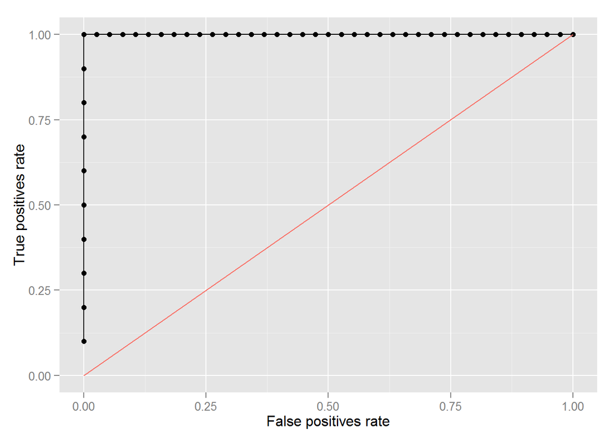

**Manhattan Plot**

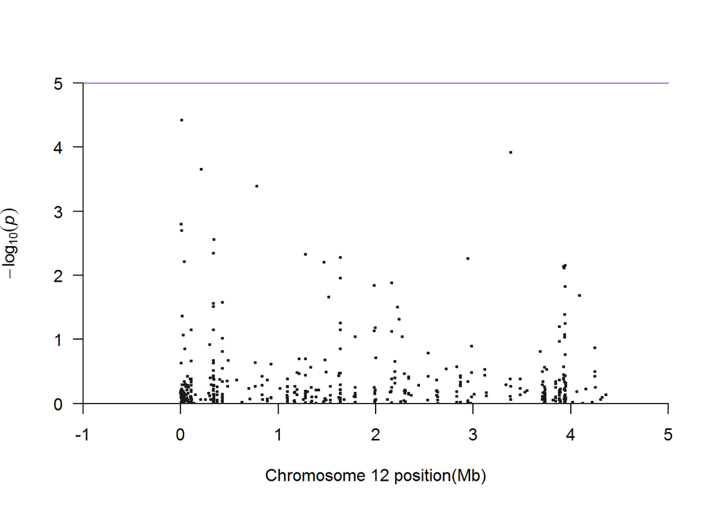

```r
manhattan(test.gwas, cex = .5)
```

**Q-Q Plot**

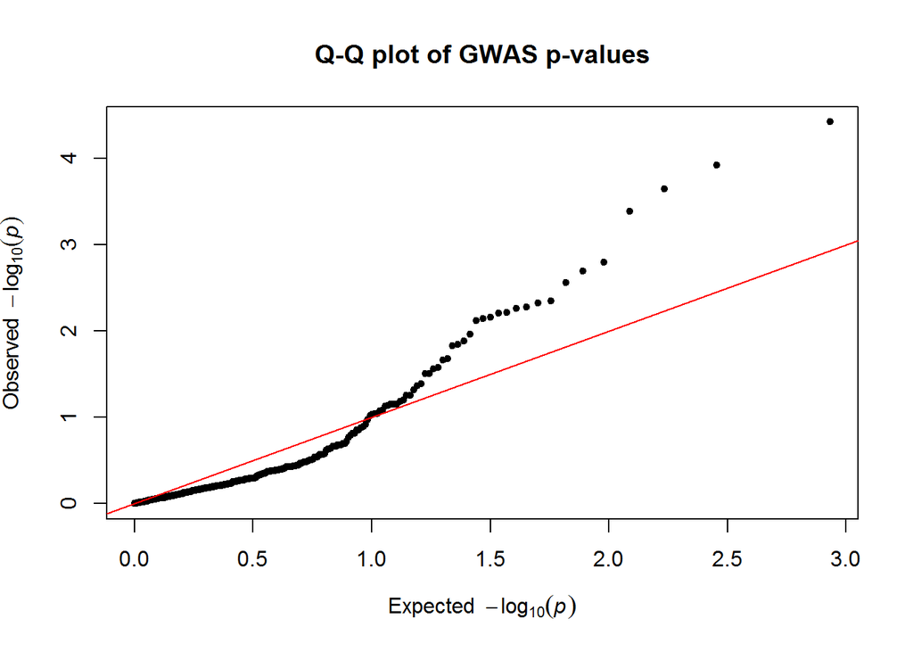

**Significant mutations**

|  | ps | allele1 | allele0 | af | p_lrt | bonferroni | holm | hochberg | fdr | BY |
| --- | --- | --- | --- | --- | --- | --- | --- | --- | --- | --- |
| 8 | 4086 | T | G | 0.250 | 0.00159731 | 0.68365 | 0.67726 | 0.67726 | 0.13673 | 0.9075 |
| 11 | 7570 | T | C | 0.083 | 0.00200527 | 0.85825 | 0.84823 | 0.84823 | 0.14304 | 0.9494 |
| 12 | 7582 | G | A | 0.104 | 0.00003758 | 0.01608 | 0.01608 | 0.01608 | 0.01608 | 0.1068 |
| 36 | 35978 | A | G | 0.062 | 0.00614638 | 1.00000 | 1.00000 | 0.99887 | 0.20358 | 1.0000 |
| 77 | 209944 | A | C | 0.042 | 0.00022262 | 0.09528 | 0.09484 | 0.09484 | 0.03176 | 0.2108 |
| 90 | 333637 | G | A | 0.125 | 0.00450430 | 1.00000 | 1.00000 | 0.99887 | 0.20358 | 1.0000 |
| 104 | 338322 | A | C | 0.021 | 0.00273207 | 1.00000 | 1.00000 | 0.99887 | 0.16705 | 1.0000 |
| 141 | 781690 | G | A | 0.333 | 0.00040533 | 0.17348 | 0.17226 | 0.17226 | 0.04337 | 0.2879 |
| 182 | 1276890 | T | C | 0.229 | 0.00472127 | 1.00000 | 1.00000 | 0.99887 | 0.20358 | 1.0000 |
| 197 | 1468465 | G | A | 0.271 | 0.00618363 | 1.00000 | 1.00000 | 0.99887 | 0.20358 | 1.0000 |
| 215 | 1636179 | G | C | 0.125 | 0.00528190 | 1.00000 | 1.00000 | 0.99887 | 0.20358 | 1.0000 |
| 312 | 2944779 | C | G | 0.417 | 0.00550161 | 1.00000 | 1.00000 | 0.99887 | 0.20358 | 1.0000 |
| 329 | 3382124 | T | C | 0.167 | 0.00011962 | 0.05120 | 0.05108 | 0.05108 | 0.02560 | 0.1699 |
| 387 | 3927774 | A | G | 0.083 | 0.00723524 | 1.00000 | 1.00000 | 0.99887 | 0.20388 | 1.0000 |
| 390 | 3931640 | G | C | 0.271 | 0.00762150 | 1.00000 | 1.00000 | 0.99887 | 0.20388 | 1.0000 |
| 409 | 3943928 | G | A | 0.062 | 0.00696691 | 1.00000 | 1.00000 | 0.99887 | 0.20388 | 1.0000 |

# Dataset: ‘dataset_4.1-S-2ndLine_R-rifm_OFLO_bin’ prediction accuracy summary

| drug | 1 | 0 | 1/1 | 1/0 | 0/1 | 0/0 | precission | recall | f1 | accuracy |
| --- | --- | --- | --- | --- | --- | --- | --- | --- | --- | --- |
| OFLO | 10 | 13 | 0.4348 | 0 | 0 | 0.5652 | 1 | 1 | 1 | 1 |
| OFLO-nodup | 10 | 13 | 0.4348 | 0 | 0 | 0.5652 | 1 | 1 | 1 | 1 |

## ‘OFLO’ Details

**ROC learning curve**

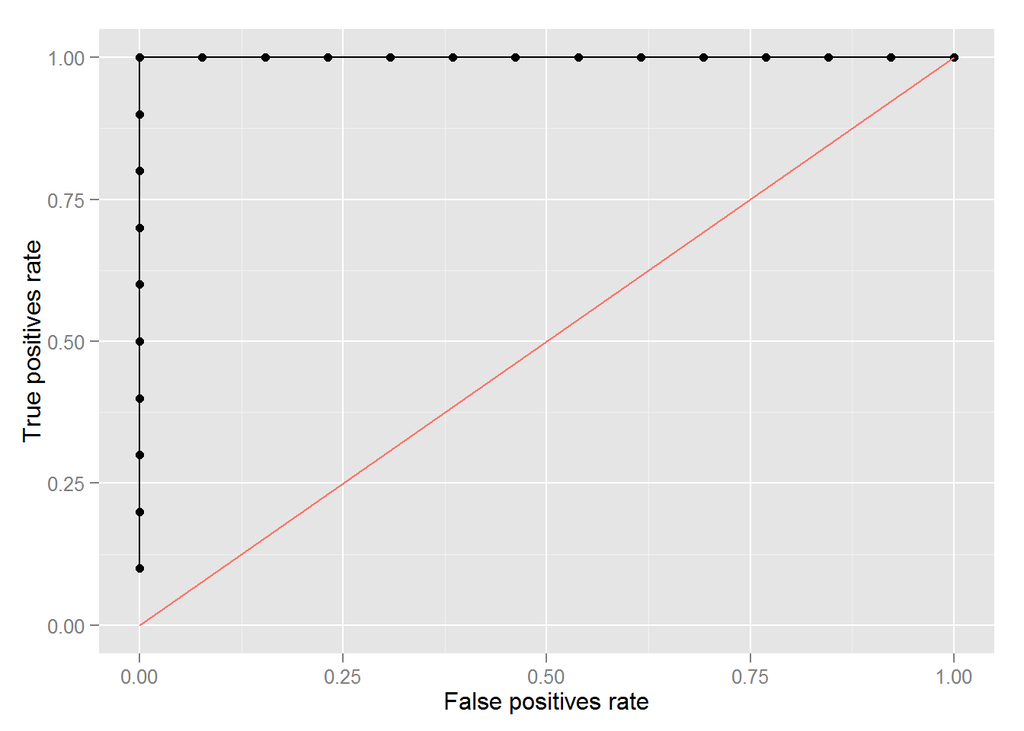

**Manhattan Plot**

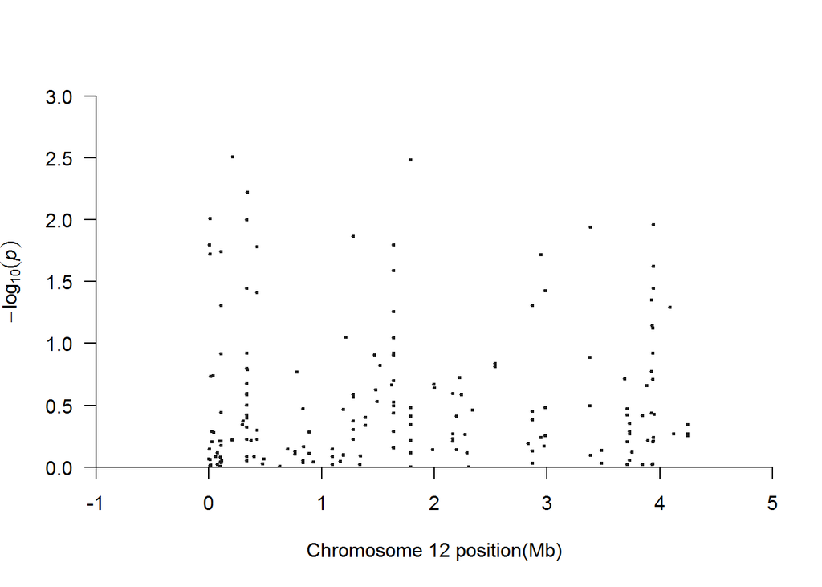

```r
manhattan(test.gwas, cex = .5)
```

**Q-Q Plot**

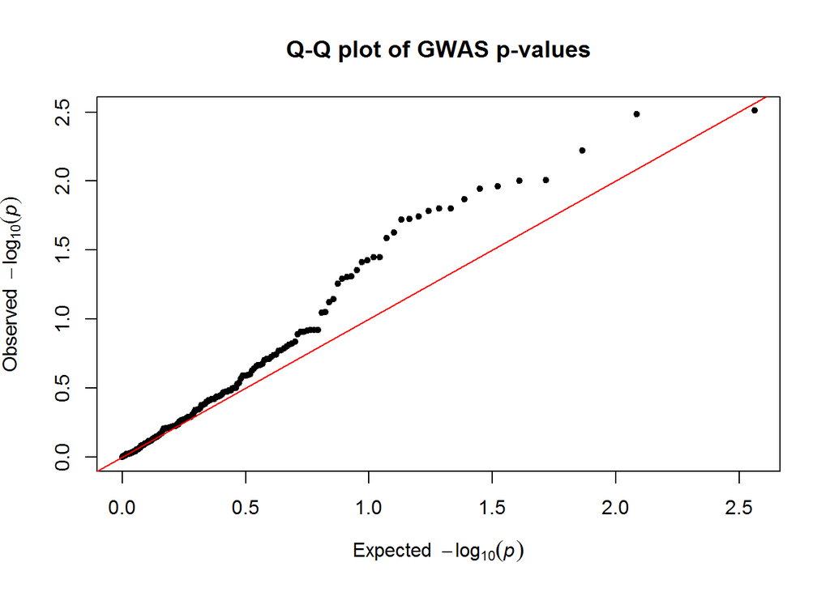

**Significant mutations**

|  | ps | allele1 | allele0 | af | p_lrt | bonferroni | holm | hochberg | fdr | BY |
| --- | --- | --- | --- | --- | --- | --- | --- | --- | --- | --- |
| 4 | 7570 | T | C | 0.174 | 0.009810 | 1.0000 | 1.0000 | 0.9937 | 0.2488 | 1 |
| 207 | 209944 | A | C | 0.087 | 0.003095 | 0.5663 | 0.5663 | 0.5663 | 0.2488 | 1 |
| 272 | 333637 | G | A | 0.261 | 0.009936 | 1.0000 | 1.0000 | 0.9937 | 0.2488 | 1 |
| 295 | 338322 | A | C | 0.043 | 0.005996 | 1.0000 | 1.0000 | 0.9937 | 0.2488 | 1 |
| 1257 | 1789523 | G | A | 0.391 | 0.003265 | 0.5974 | 0.5942 | 0.5942 | 0.2488 | 1 |

## ‘OFLO-nodup’ Details

**ROC learning curve**

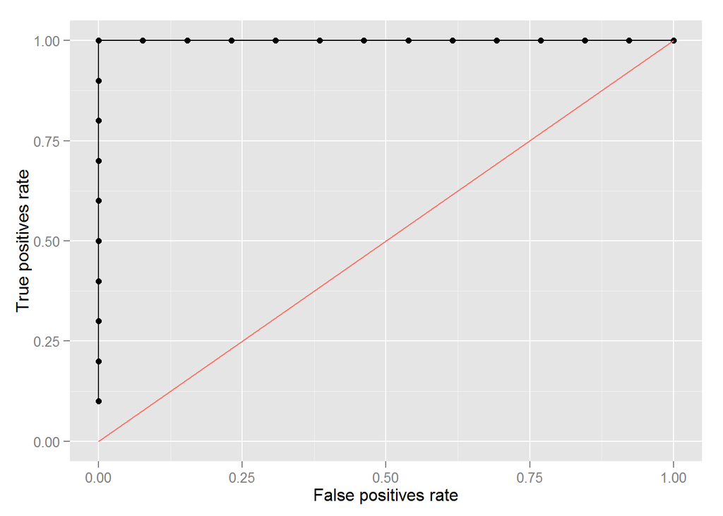

**Manhattan Plot**

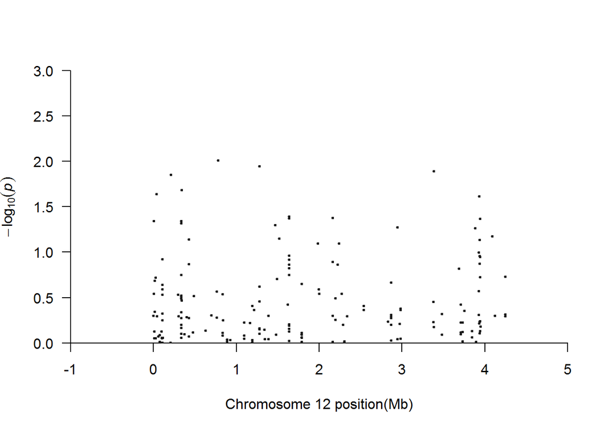

```r
manhattan(test.gwas, cex = .5)
```

**Q-Q Plot**

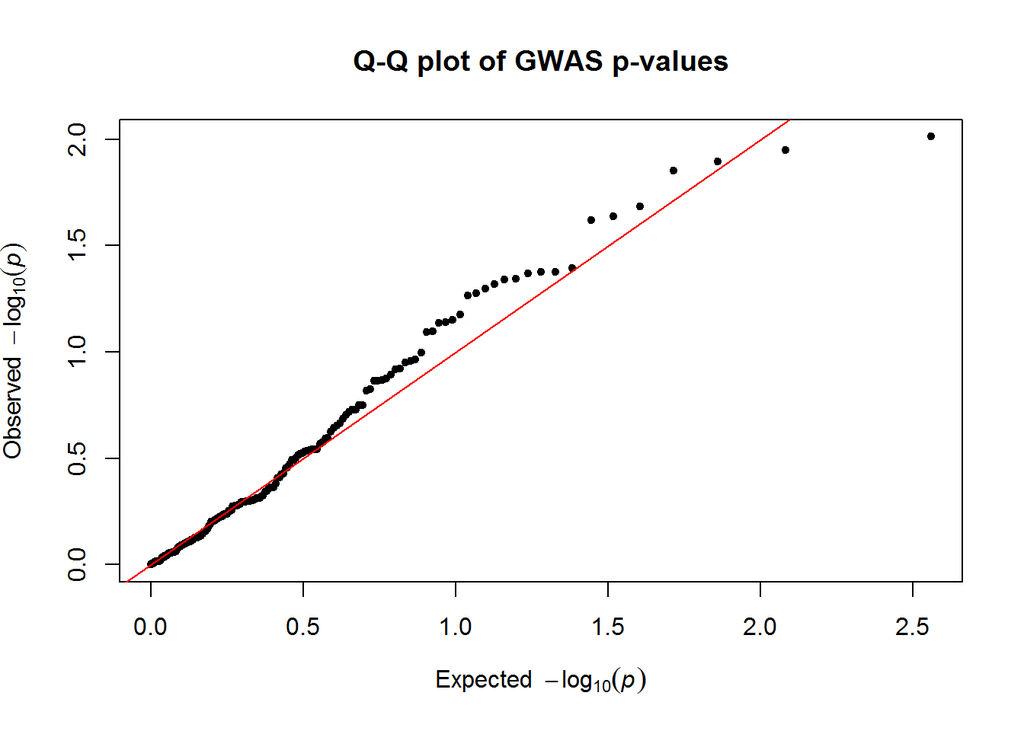

**Significant mutations**

|  | ps | allele1 | allele0 | af | p_lrt | bonferroni | holm | hochberg | fdr | BY |
| --- | --- | --- | --- | --- | --- | --- | --- | --- | --- | --- |
| 59 | 781690 | A | G | 0.304 | 0.009743 | 1 | 1 | 0.9978 | 0.5811 | 1 |

# Dataset: ‘dataset_5-S-ami_capr_bin’ prediction accuracy summary

| drug | 1 | 0 | 1/1 | 1/0 | 0/1 | 0/0 | precission | recall | f1 | accuracy |
| --- | --- | --- | --- | --- | --- | --- | --- | --- | --- | --- |
| CAPR | 7 | 51 | 0.1207 | 0 | 0.2414 | 0.6379 | 0.3333 | 1 | 0.5000 | 0.7586 |
| CAPR-nodup | 7 | 51 | 0.1207 | 0 | 0.2241 | 0.6552 | 0.3500 | 1 | 0.5185 | 0.7759 |

## ‘CAPR’ Details

**ROC learning curve**

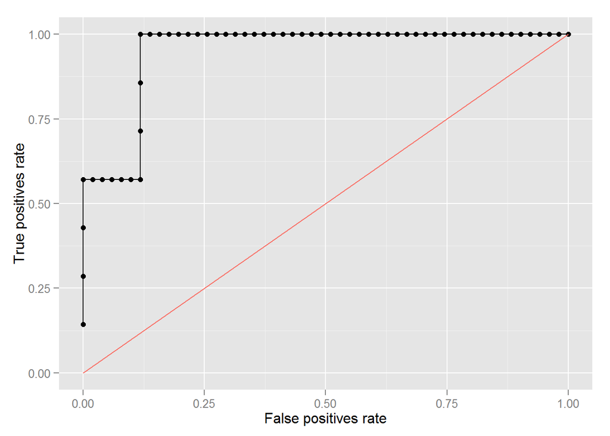

**Manhattan Plot**

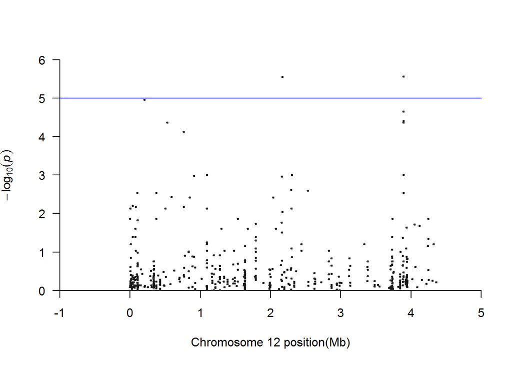

```r
manhattan(test.gwas, cex = .5)
```

**Q-Q Plot**

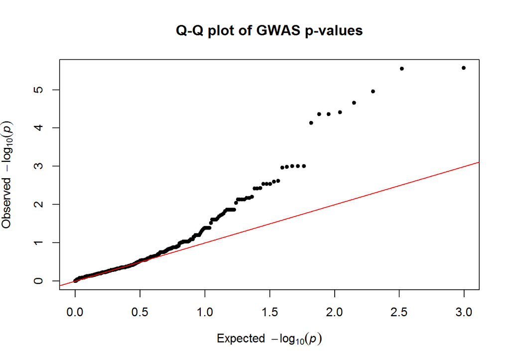

**Significant mutations**

|  | ps | allele1 | allele0 | af | p_lrt | bonferroni | holm | hochberg | fdr | BY |
| --- | --- | --- | --- | --- | --- | --- | --- | --- | --- | --- |
| 10 | 6620 | A | G | 0.017 | 0.007403667 | 1.000000 | 1.000000 | 0.998484 | 0.1308863 | 0.887774 |
| 65 | 35978 | A | G | 0.138 | 0.006293242 | 1.000000 | 1.000000 | 0.998484 | 0.1308863 | 0.887774 |
| 130 | 78033 | C | T | 0.190 | 0.006786272 | 1.000000 | 1.000000 | 0.998484 | 0.1308863 | 0.887774 |
| 159 | 103599 | G | C | 0.172 | 0.002880258 | 1.000000 | 1.000000 | 0.998484 | 0.0792071 | 0.537245 |
| 303 | 202369 | C | G | 0.034 | 0.000010998 | 0.005444 | 0.005422 | 0.005422 | 0.0018147 | 0.012309 |
| 562 | 370328 | T | C | 0.172 | 0.002880257 | 1.000000 | 1.000000 | 0.998484 | 0.0792071 | 0.537245 |
| 709 | 501862 | A | G | 0.017 | 0.007403667 | 1.000000 | 1.000000 | 0.998484 | 0.1308863 | 0.887774 |
| 730 | 528976 | T | C | 0.034 | 0.000043314 | 0.021440 | 0.021224 | 0.021181 | 0.0030629 | 0.020775 |
| 791 | 592300 | T | C | 0.017 | 0.003754198 | 1.000000 | 1.000000 | 0.998484 | 0.0900959 | 0.611101 |
| 940 | 761142 | G | C | 0.190 | 0.006786267 | 1.000000 | 1.000000 | 0.998484 | 0.1308863 | 0.887774 |
| 947 | 764825 | T | G | 0.086 | 0.000074122 | 0.036690 | 0.036171 | 0.036171 | 0.0045863 | 0.031108 |
| 1050 | 852507 | G | A | 0.017 | 0.003776885 | 1.000000 | 1.000000 | 0.998484 | 0.0900959 | 0.611101 |
| 1115 | 908189 | C | T | 0.448 | 0.001032886 | 0.511279 | 0.499917 | 0.499917 | 0.0415483 | 0.281813 |
| 1310 | 1096006 | T | C | 0.155 | 0.000987726 | 0.488925 | 0.481017 | 0.479048 | 0.0415483 | 0.281813 |
| 1312 | 1096102 | A | G | 0.017 | 0.007403663 | 1.000000 | 1.000000 | 0.998484 | 0.1308863 | 0.887774 |
| 2367 | 2039487 | T | C | 0.017 | 0.003822252 | 1.000000 | 1.000000 | 0.998484 | 0.0900959 | 0.611101 |
| 2505 | 2163357 | T | C | 0.052 | 0.001091168 | 0.540128 | 0.527034 | 0.527034 | 0.0415483 | 0.281813 |
| 2541 | 2169051 | G | C | 0.069 | 0.009005109 | 1.000000 | 1.000000 | 0.998484 | 0.1537079 | 1.000000 |
| 2547 | 2169072 | T | C | 0.069 | 0.000002802 | 0.001387 | 0.001384 | 0.001384 | 0.0006935 | 0.004704 |
| 2730 | 2295693 | A | C | 0.431 | 0.002391012 | 1.000000 | 1.000000 | 0.998484 | 0.0792071 | 0.537245 |
| 2736 | 2300214 | C | T | 0.017 | 0.007403671 | 1.000000 | 1.000000 | 0.998484 | 0.1308863 | 0.887774 |
| 2754 | 2301790 | C | T | 0.155 | 0.000987714 | 0.488918 | 0.481017 | 0.479048 | 0.0415483 | 0.281813 |
| 3062 | 2531974 | G | C | 0.103 | 0.002546497 | 1.000000 | 1.000000 | 0.998484 | 0.0792071 | 0.537245 |
| 4570 | 3895246 | C | A | 0.155 | 0.000987728 | 0.488925 | 0.481017 | 0.479048 | 0.0415483 | 0.281813 |
| 4571 | 3895247 | A | G | 0.172 | 0.002880257 | 1.000000 | 1.000000 | 0.998484 | 0.0792071 | 0.537245 |
| 4572 | 3895256 | A | G | 0.121 | 0.000038922 | 0.019267 | 0.019111 | 0.019111 | 0.0030629 | 0.020775 |
| 4576 | 3895261 | G | A | 0.103 | 0.000002715 | 0.001344 | 0.001344 | 0.001344 | 0.0006935 | 0.004704 |
| 4577 | 3895282 | C | G | 0.069 | 0.000022015 | 0.010897 | 0.010831 | 0.010831 | 0.0027243 | 0.018478 |
| 4578 | 3895290 | A | C | 0.034 | 0.000043314 | 0.021440 | 0.021224 | 0.021181 | 0.0030629 | 0.020775 |

## ‘CAPR-nodup’ Details

**ROC learning curve**

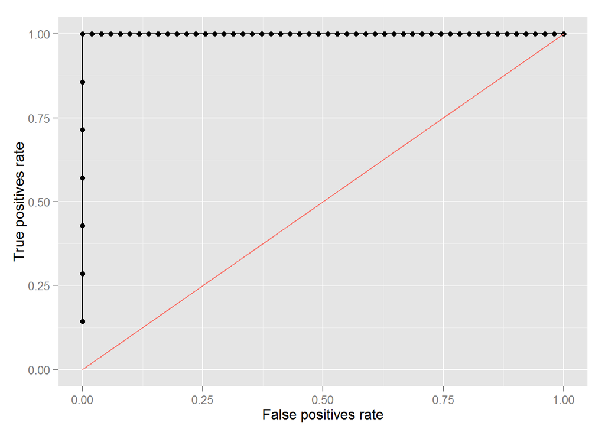

**Manhattan Plot**

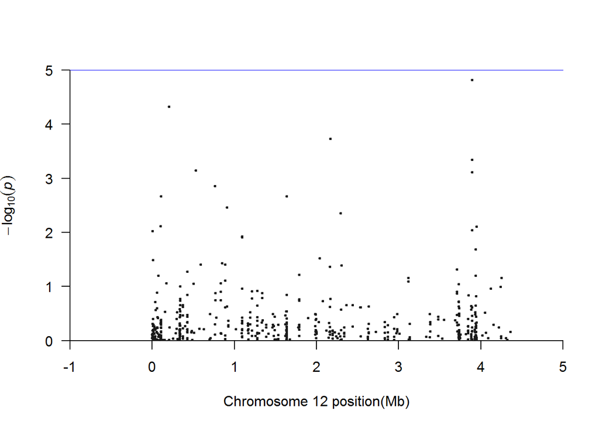

```r
manhattan(test.gwas, cex = .5)
```

**Q-Q Plot**

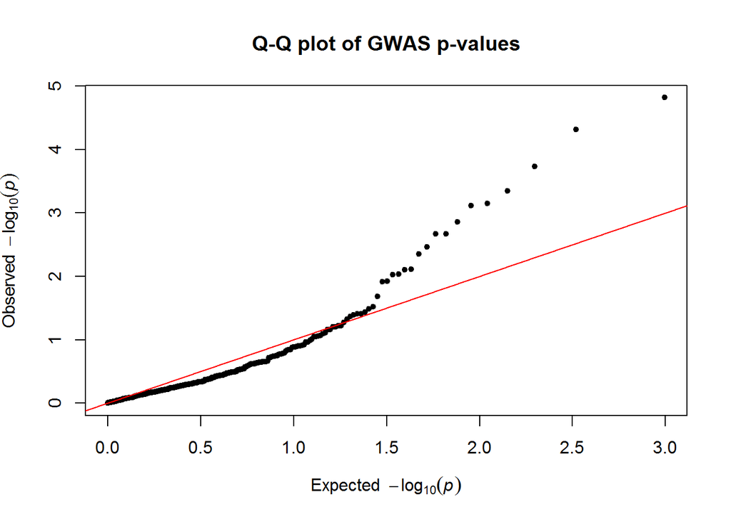

**Significant mutations**

|  | ps | allele1 | allele0 | af | p_lrt | bonferroni | holm | hochberg | fdr | BY |
| --- | --- | --- | --- | --- | --- | --- | --- | --- | --- | --- |
| 10 | 6620 | A | G | 0.017 | 0.00942325 | 1.000000 | 1.000000 | 0.998532 | 0.310967 | 1.00000 |
| 54 | 101249 | T | G | 0.017 | 0.00772360 | 1.000000 | 1.000000 | 0.998532 | 0.300228 | 1.00000 |
| 65 | 104912 | C | T | 0.121 | 0.00215040 | 1.000000 | 1.000000 | 0.998532 | 0.118272 | 0.80221 |
| 80 | 202369 | C | G | 0.034 | 0.00004789 | 0.023705 | 0.023657 | 0.023657 | 0.011852 | 0.08039 |
| 148 | 528976 | T | C | 0.034 | 0.00071183 | 0.352358 | 0.349511 | 0.349511 | 0.063604 | 0.43141 |
| 157 | 764825 | T | G | 0.086 | 0.00140018 | 0.693089 | 0.684688 | 0.684688 | 0.099013 | 0.67158 |
| 172 | 908189 | C | T | 0.448 | 0.00345171 | 1.000000 | 1.000000 | 0.998532 | 0.170860 | 1.00000 |
| 252 | 1636924 | T | C | 0.172 | 0.00213496 | 1.000000 | 1.000000 | 0.998532 | 0.118272 | 0.80221 |
| 311 | 2169072 | T | C | 0.069 | 0.00018447 | 0.091314 | 0.090945 | 0.090945 | 0.030438 | 0.20645 |
| 322 | 2295693 | A | C | 0.431 | 0.00445671 | 1.000000 | 1.000000 | 0.998532 | 0.200552 | 1.00000 |
| 442 | 3895256 | A | G | 0.121 | 0.00044968 | 0.222594 | 0.221245 | 0.221245 | 0.055648 | 0.37745 |
| 443 | 3895261 | G | A | 0.103 | 0.00001521 | 0.007527 | 0.007527 | 0.007527 | 0.007527 | 0.05105 |
| 444 | 3895282 | C | G | 0.069 | 0.00915400 | 1.000000 | 1.000000 | 0.998532 | 0.310967 | 1.00000 |
| 445 | 3895290 | A | C | 0.034 | 0.00077096 | 0.381626 | 0.377771 | 0.377771 | 0.063604 | 0.43141 |
| 477 | 3946974 | G | C | 0.052 | 0.00788477 | 1.000000 | 1.000000 | 0.998532 | 0.300228 | 1.00000 |

# Dataset: ‘dataset_6-2ndLine_Inj_bin’ prediction accuracy summary

| drug | 1 | 0 | 1/1 | 1/0 | 0/1 | 0/0 | precission | recall | f1 | accuracy |
| --- | --- | --- | --- | --- | --- | --- | --- | --- | --- | --- |
| AMIK | 59 | 63 | 0.4836 | 0 | 0.5164 | 0 | 0.4836 | 1 | 0.6519 | 0.4836 |
| AMIK-nodup | 59 | 63 | 0.4836 | 0 | 0.5164 | 0 | 0.4836 | 1 | 0.6519 | 0.4836 |
| CAPR | 66 | 51 | 0.5641 | 0 | 0.4359 | 0 | 0.5641 | 1 | 0.7213 | 0.5641 |
| CAPR-nodup | 66 | 51 | 0.5641 | 0 | 0.4359 | 0 | 0.5641 | 1 | 0.7213 | 0.5641 |

## ‘AMIK’ Details

**ROC learning curve**

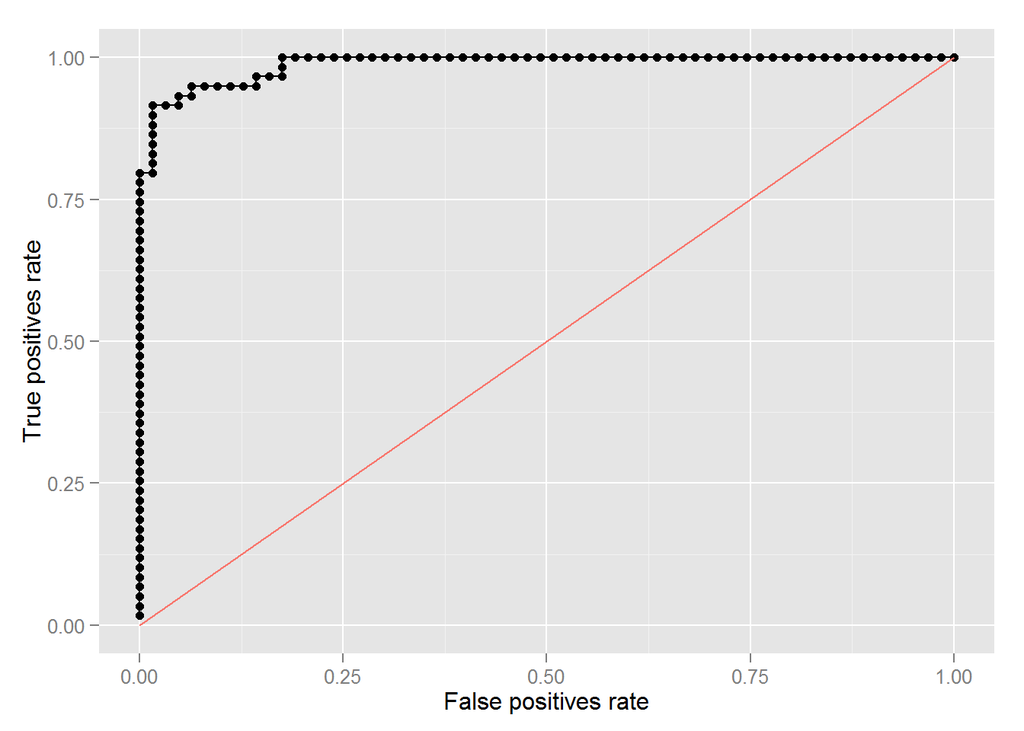

**Manhattan Plot**

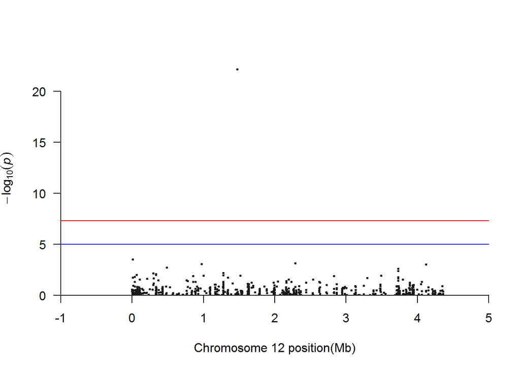

```r
manhattan(test.gwas, cex = .5)
```

**Q-Q Plot**

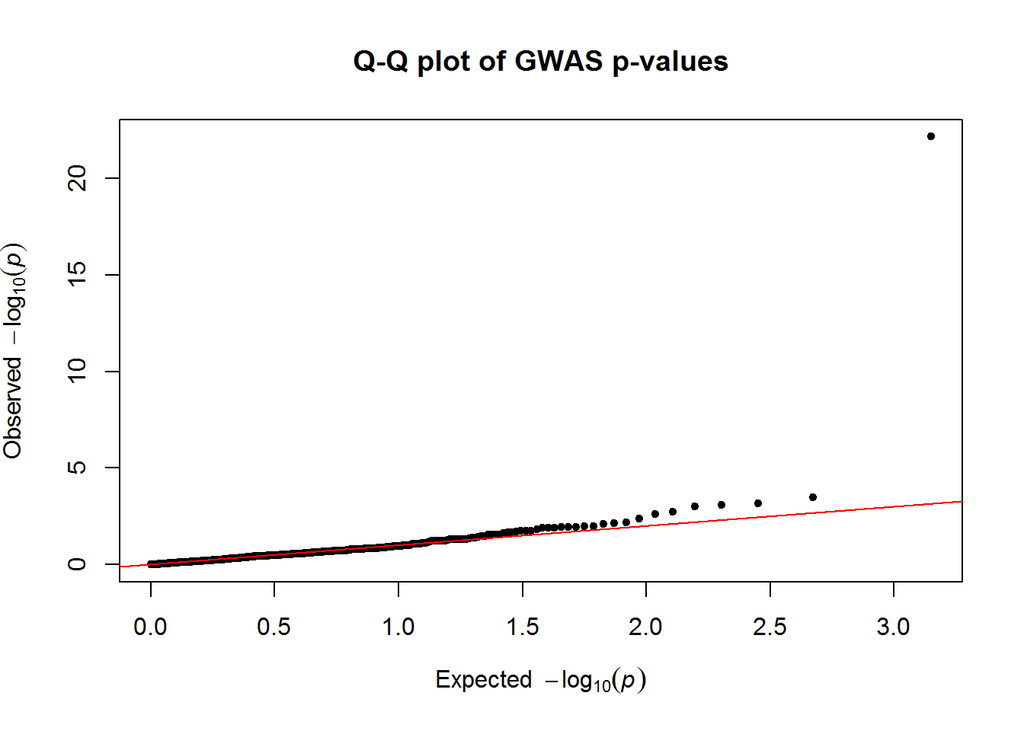

**Significant mutations**

|  | ps | allele1 | allele0 | af | p_lrt | bonferroni | holm | hochberg | fdr | BY |
| --- | --- | --- | --- | --- | --- | --- | --- | --- | --- | --- |
| 13 | 7581 | A | G | 0.041 | 0.0003195 | 0.22527400799999999781 | 0.22495447039999999506 | 0.22495447039999999506 | 0.11263700399999999890 | 0.80379146081933627865 |
| 331 | 295731 | C | T | 0.180 | 0.0071526 | 1.00000000000000000000 | 1.00000000000000000000 | 0.99891220000000002788 | 0.48555093947368421770 | 1.00000000000000000000 |
| 375 | 333628 | A | G | 0.369 | 0.0081340 | 1.00000000000000000000 | 1.00000000000000000000 | 0.99891220000000002788 | 0.48555093947368421770 | 1.00000000000000000000 |
| 585 | 487328 | T | C | 0.016 | 0.0019346 | 1.00000000000000000000 | 1.00000000000000000000 | 0.99891220000000002788 | 0.22731937750000000276 | 1.00000000000000000000 |
| 1010 | 973064 | C | G | 0.131 | 0.0008504 | 0.59951895750000006036 | 0.59696781300000001380 | 0.59696781300000001380 | 0.13631382270000000356 | 0.97275213994417852881 |
| 1308 | 1276887 | G | C | 0.090 | 0.0065461 | 1.00000000000000000000 | 1.00000000000000000000 | 0.99891220000000002788 | 0.48555093947368421770 | 1.00000000000000000000 |
| 1466 | 1473252 | G | A | 0.393 | 0.0000000 | 0.00000000000000000005 | 0.00000000000000000005 | 0.00000000000000000005 | 0.00000000000000000005 | 0.00000000000000000035 |
| 2325 | 2289048 | C | A | 0.180 | 0.0007139 | 0.50326664700000001140 | 0.50183894019999997216 | 0.50183894019999997216 | 0.13631382270000000356 | 0.97275213994417852881 |
| 3563 | 3730787 | A | G | 0.148 | 0.0024656 | 1.00000000000000000000 | 1.00000000000000000000 | 0.99891220000000002788 | 0.24831781928571428075 | 1.00000000000000000000 |
| 3574 | 3732541 | G | A | 0.131 | 0.0043233 | 1.00000000000000000000 | 1.00000000000000000000 | 0.99891220000000002788 | 0.38099187000000006575 | 1.00000000000000000000 |
| 4089 | 4121290 | A | C | 0.172 | 0.0009668 | 0.68156911349999993455 | 0.67770205470000000059 | 0.67770205470000000059 | 0.13631382270000000356 | 0.97275213994417852881 |

## ‘AMIK-nodup’ Details

**ROC learning curve**

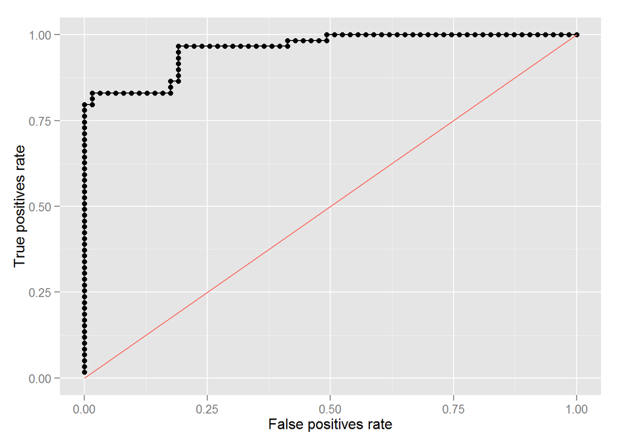

**Manhattan Plot**

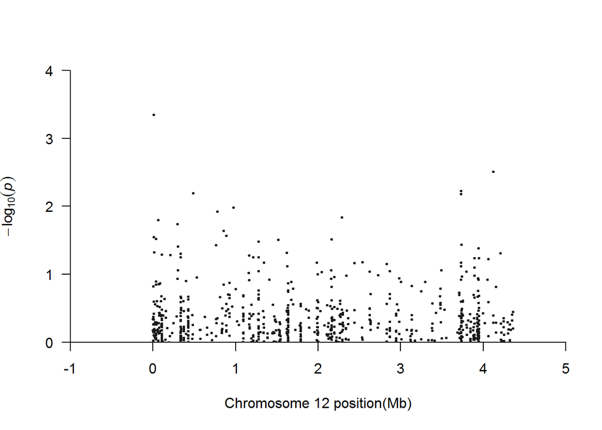

```r
manhattan(test.gwas, cex = .5)
```

**Q-Q Plot**

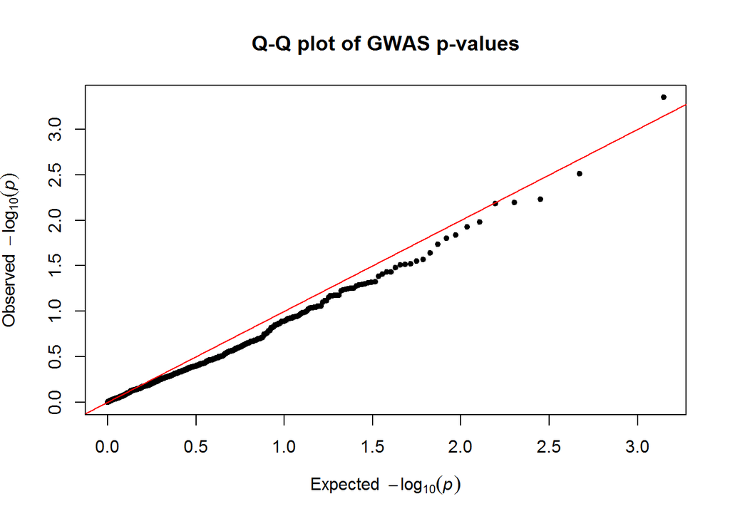

**Significant mutations**

|  | ps | allele1 | allele0 | af | p_lrt | bonferroni | holm | hochberg | fdr | BY |
| --- | --- | --- | --- | --- | --- | --- | --- | --- | --- | --- |
| 12 | 7581 | A | G | 0.041 | 0.0004493 | 0.3163 | 0.3163 | 0.3163 | 0.3163 | 1 |
| 166 | 487328 | T | C | 0.016 | 0.0063993 | 1.0000 | 1.0000 | 0.9986 | 0.9305 | 1 |
| 550 | 3730787 | A | G | 0.148 | 0.0066083 | 1.0000 | 1.0000 | 0.9986 | 0.9305 | 1 |
| 556 | 3732541 | G | A | 0.131 | 0.0059048 | 1.0000 | 1.0000 | 0.9986 | 0.9305 | 1 |
| 678 | 4121290 | A | C | 0.172 | 0.0030790 | 1.0000 | 1.0000 | 0.9986 | 0.9305 | 1 |

## ‘CAPR’ Details

**ROC learning curve**

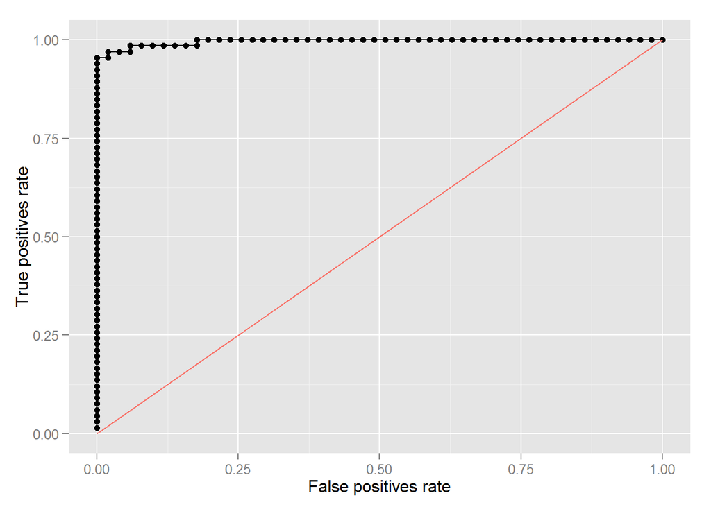

**Manhattan Plot**

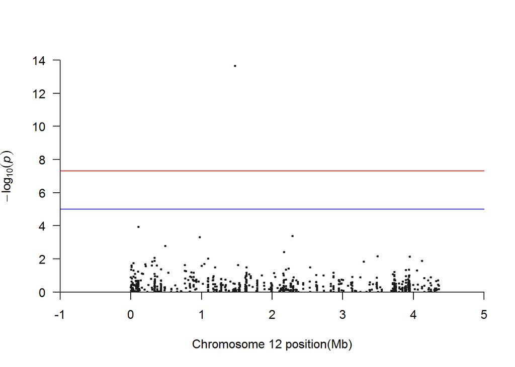

```r
manhattan(test.gwas, cex = .5)
```

**Q-Q Plot**

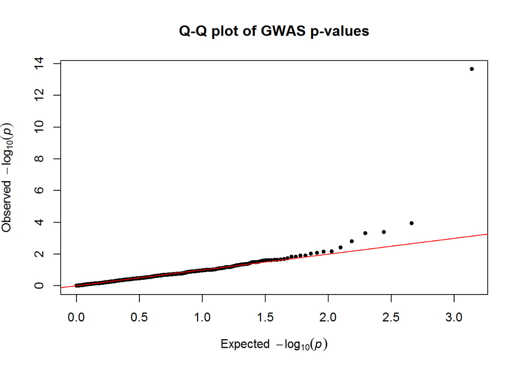

**Significant mutations**

|  | ps | allele1 | allele0 | af | p_lrt | bonferroni | holm | hochberg | fdr | BY |
| --- | --- | --- | --- | --- | --- | --- | --- | --- | --- | --- |
| 154 | 104912 | C | T | 0.060 | 0.00011422600000000 | 0.07893016600000 | 0.07881594000000 | 0.07881594000000 | 0.03946508300000 | 0.2808366445471 |
| 355 | 333628 | A | G | 0.376 | 0.00869135900000000 | 1.00000000000000 | 1.00000000000000 | 0.99899660000000 | 0.66730322988889 | 1.0000000000000 |
| 557 | 487328 | T | C | 0.017 | 0.00161340200000000 | 1.00000000000000 | 1.00000000000000 | 0.99899660000000 | 0.22297215640000 | 1.0000000000000 |
| 959 | 973064 | C | G | 0.137 | 0.00049170710000000 | 0.33976960610000 | 0.33829448480000 | 0.33829448480000 | 0.08494240152500 | 0.6044568314744 |
| 1055 | 1096006 | T | C | 0.145 | 0.00969467000000000 | 1.00000000000000 | 1.00000000000000 | 0.99899660000000 | 0.66990169700000 | 1.0000000000000 |
| 1378 | 1473252 | G | A | 0.410 | 0.00000000000002249 | 0.00000000001554 | 0.00000000001554 | 0.00000000001554 | 0.00000000001554 | 0.0000000001106 |
| 2031 | 2169072 | T | C | 0.051 | 0.00383913400000000 | 1.00000000000000 | 1.00000000000000 | 0.99899660000000 | 0.44214026566667 | 1.0000000000000 |
| 2178 | 2289048 | C | A | 0.188 | 0.00040801610000000 | 0.28193912510000 | 0.28112309290000 | 0.28112309290000 | 0.08494240152500 | 0.6044568314744 |
| 3190 | 3491581 | C | G | 0.145 | 0.00697788100000000 | 1.00000000000000 | 1.00000000000000 | 0.99899660000000 | 0.61322682712500 | 1.0000000000000 |
| 3694 | 3946974 | G | C | 0.034 | 0.00709958700000000 | 1.00000000000000 | 1.00000000000000 | 0.99899660000000 | 0.61322682712500 | 1.0000000000000 |

## ‘CAPR-nodup’ Details

**ROC learning curve**

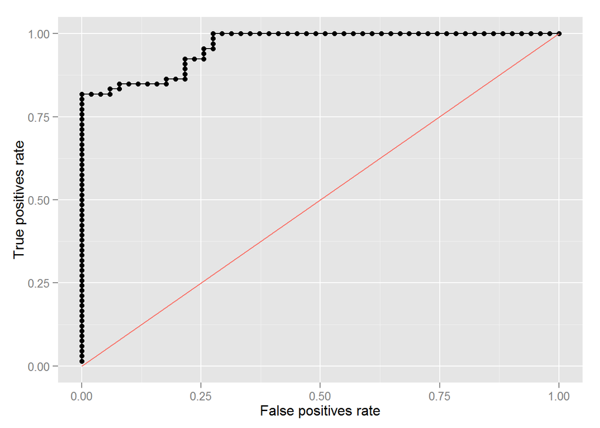

**Manhattan Plot**

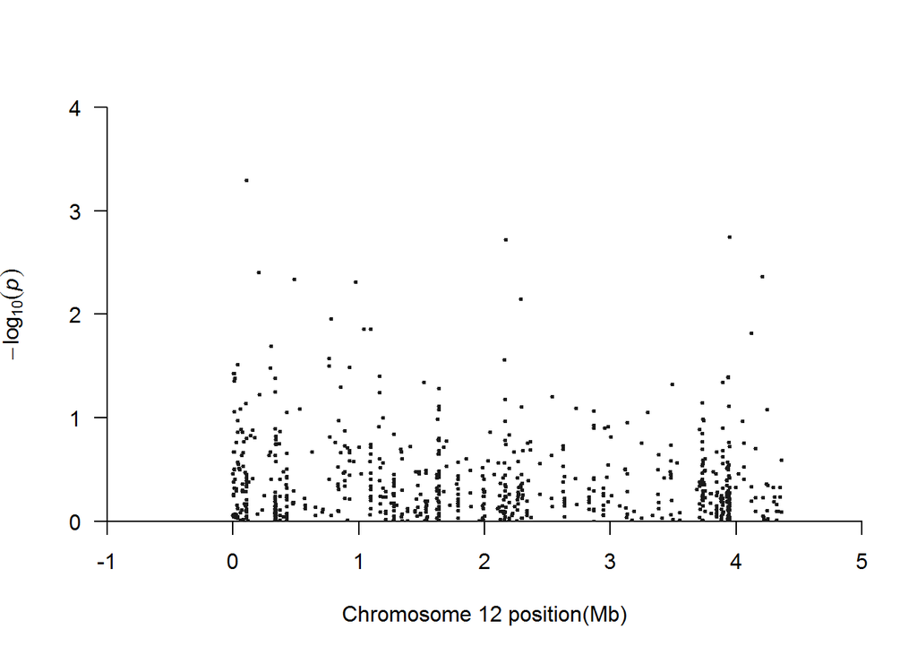

```r
manhattan(test.gwas, cex = .5)
```

**Q-Q Plot**

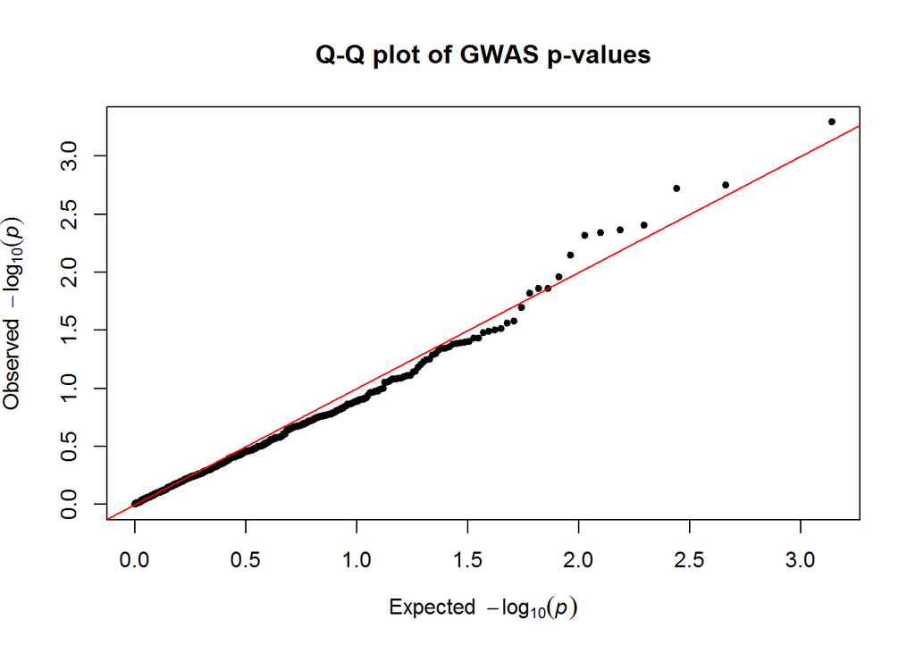

**Significant mutations**

|  | ps | allele1 | allele0 | af | p_lrt | bonferroni | holm | hochberg | fdr | BY |
| --- | --- | --- | --- | --- | --- | --- | --- | --- | --- | --- |
| 64 | 104912 | C | T | 0.060 | 0.0005106 | 0.3523 | 0.3523 | 0.3523 | 0.3523 | 1 |
| 83 | 202369 | C | G | 0.017 | 0.0039246 | 1.0000 | 1.0000 | 0.9986 | 0.4776 | 1 |
| 162 | 487328 | T | C | 0.017 | 0.0045665 | 1.0000 | 1.0000 | 0.9986 | 0.4776 | 1 |
| 204 | 973064 | C | G | 0.137 | 0.0048457 | 1.0000 | 1.0000 | 0.9986 | 0.4776 | 1 |
| 401 | 2169072 | T | C | 0.051 | 0.0018960 | 1.0000 | 1.0000 | 0.9986 | 0.4361 | 1 |
| 423 | 2289048 | C | A | 0.188 | 0.0071476 | 1.0000 | 1.0000 | 0.9986 | 0.6165 | 1 |
| 646 | 3946974 | G | C | 0.034 | 0.0017833 | 1.0000 | 1.0000 | 0.9986 | 0.4361 | 1 |
| 669 | 4210452 | A | G | 0.017 | 0.0043203 | 1.0000 | 1.0000 | 0.9986 | 0.4776 | 1 |

# Dataset: ‘dataset_7-S-oflo_R-rifm_bin’ prediction accuracy summary

| drug | 1 | 0 | 1/1 | 1/0 | 0/1 | 0/0 | precission | recall | f1 | accuracy |
| --- | --- | --- | --- | --- | --- | --- | --- | --- | --- | --- |
| AMIK | 8 | 21 | 0.2759 | 0 | 0.2759 | 0.4483 | 0.5000 | 1 | 0.6667 | 0.7241 |
| AMIK-nodup | 8 | 21 | 0.2759 | 0 | 0.7241 | 0.0000 | 0.2759 | 1 | 0.4324 | 0.2759 |
| CAPR | 10 | 18 | 0.3571 | 0 | 0.2143 | 0.4286 | 0.6250 | 1 | 0.7692 | 0.7857 |
| CAPR-nodup | 10 | 18 | 0.3571 | 0 | 0.5714 | 0.0714 | 0.3846 | 1 | 0.5556 | 0.4286 |

## ‘AMIK’ Details

**ROC learning curve**

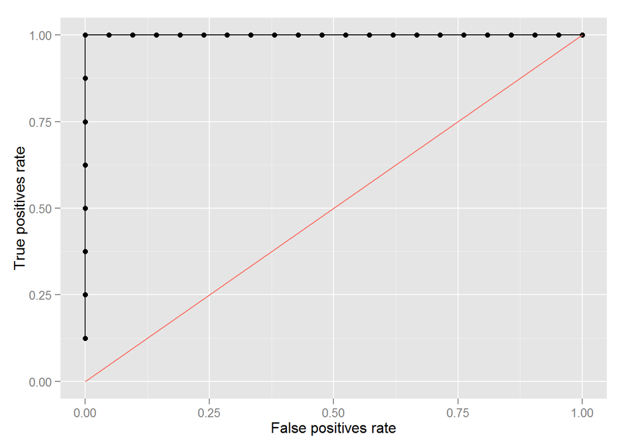

**Manhattan Plot**

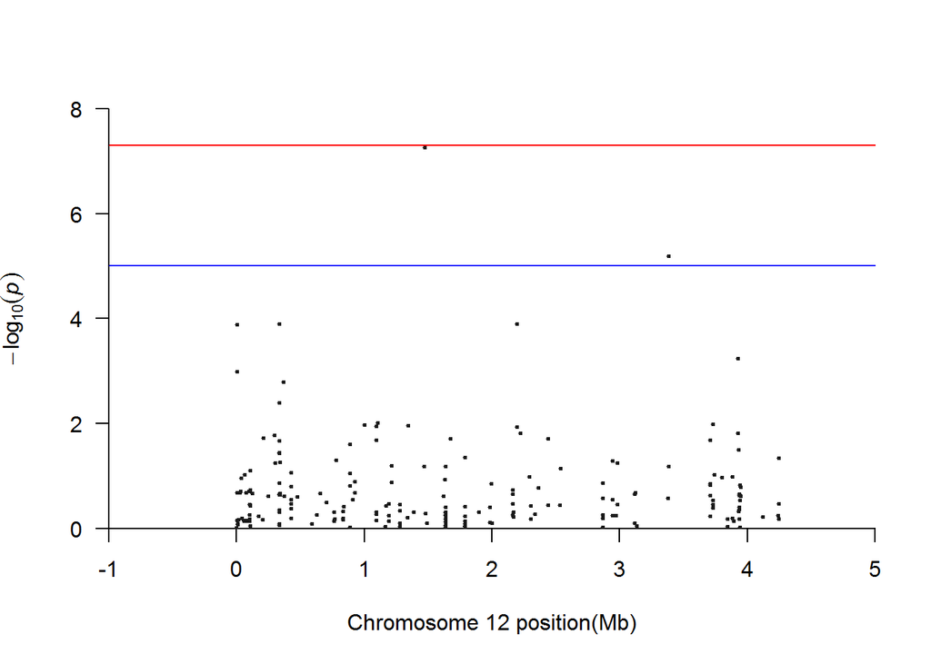

```r
manhattan(test.gwas, cex = .5)
```

**Q-Q Plot**

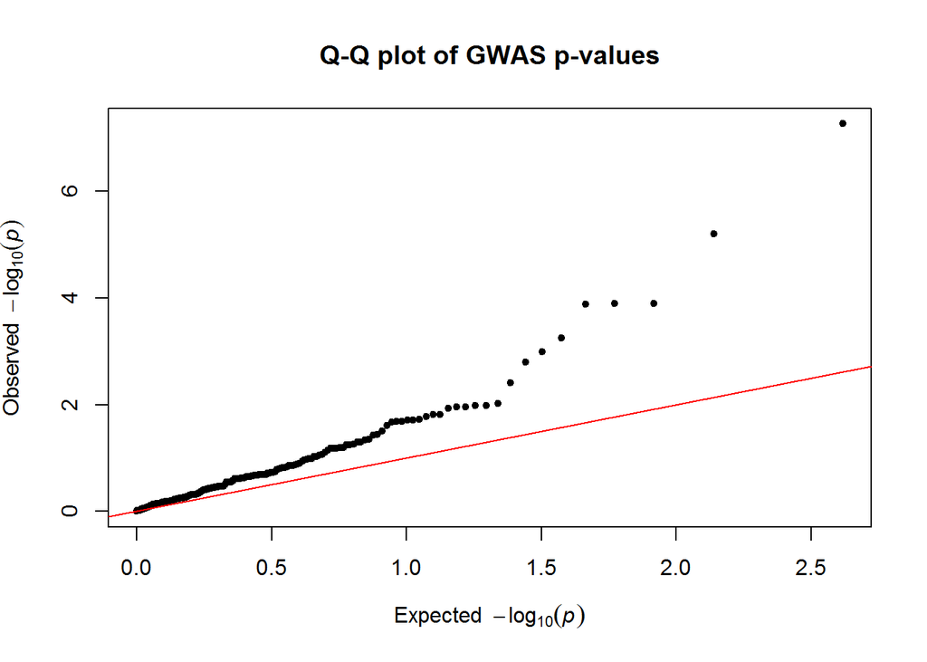

**Significant mutations**

|  | ps | allele1 | allele0 | af | p_lrt | bonferroni | holm | hochberg | fdr | BY |
| --- | --- | --- | --- | --- | --- | --- | --- | --- | --- | --- |
| 4 | 4086 | T | G | 0.379 | 0.00103363900 | 0.21396327 | 0.20776144 | 0.20776144 | 0.03056618 | 0.18071790 |
| 5 | 6579 | T | C | 0.034 | 0.00013196900 | 0.02731758 | 0.02678971 | 0.02678971 | 0.00546352 | 0.03230221 |
| 269 | 333624 | G | T | 0.345 | 0.00012614240 | 0.02611148 | 0.02585917 | 0.02573305 | 0.00546352 | 0.03230221 |
| 271 | 333632 | T | A | 0.310 | 0.00396981100 | 0.82175088 | 0.78999239 | 0.78999239 | 0.09130565 | 0.53983079 |
| 328 | 365328 | C | T | 0.172 | 0.00160484600 | 0.33220312 | 0.32096920 | 0.32096920 | 0.04152539 | 0.24551256 |
| 838 | 1104278 | C | T | 0.034 | 0.00959248800 | 1.00000000 | 1.00000000 | 0.99571510 | 0.16184116 | 0.95686123 |
| 1079 | 1473252 | G | A | 0.207 | 0.00000005451 | 0.00001128 | 0.00001128 | 0.00001128 | 0.00001128 | 0.00006671 |
| 1616 | 2196889 | G | A | 0.345 | 0.00012614230 | 0.02611146 | 0.02585917 | 0.02573305 | 0.00546352 | 0.03230221 |
| 2361 | 3382124 | T | C | 0.310 | 0.00000636278 | 0.00131710 | 0.00131073 | 0.00131073 | 0.00065855 | 0.00389357 |
| 2780 | 3927774 | A | G | 0.138 | 0.00057156570 | 0.11831410 | 0.11545627 | 0.11545627 | 0.01971902 | 0.11658569 |

## ‘AMIK-nodup’ Details

**ROC learning curve**

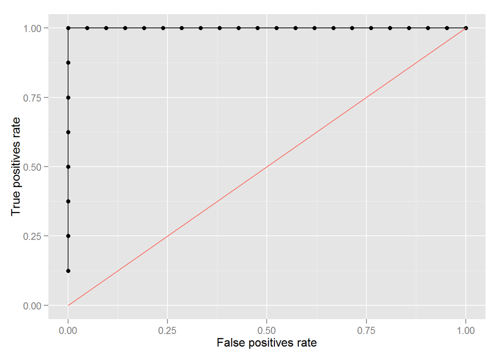

**Manhattan Plot**

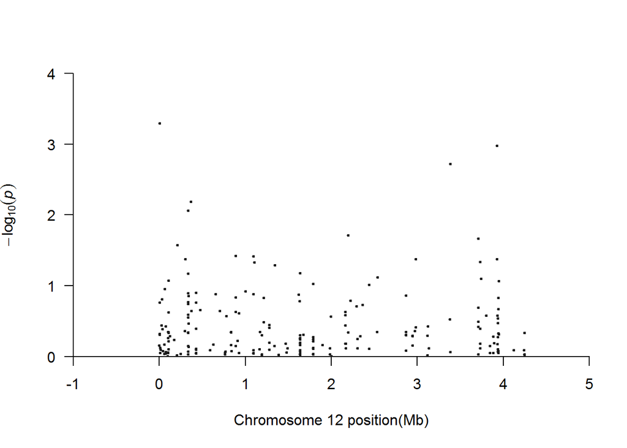

```r
manhattan(test.gwas, cex = .5)
```

**Q-Q Plot**

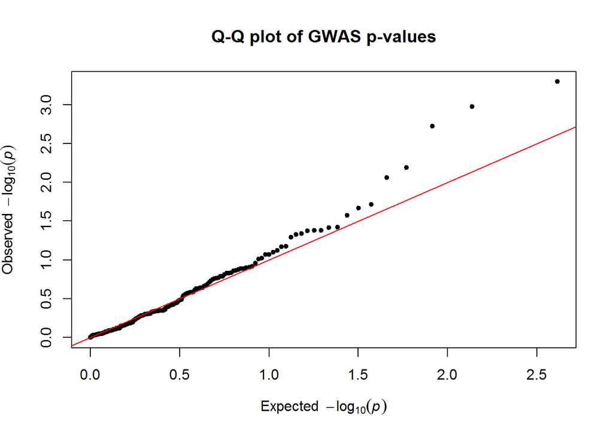

**Significant mutations**

|  | ps | allele1 | allele0 | af | p_lrt | bonferroni | holm | hochberg | fdr | BY |
| --- | --- | --- | --- | --- | --- | --- | --- | --- | --- | --- |
| 5 | 6579 | T | C | 0.034 | 0.0005066 | 0.1044 | 0.1044 | 0.1044 | 0.1044 | 0.6165 |
| 37 | 333624 | G | T | 0.345 | 0.0086615 | 1.0000 | 1.0000 | 0.9950 | 0.3569 | 1.0000 |
| 52 | 365328 | C | T | 0.172 | 0.0065020 | 1.0000 | 1.0000 | 0.9950 | 0.3349 | 1.0000 |
| 169 | 3382124 | T | C | 0.310 | 0.0018901 | 0.3894 | 0.3856 | 0.3856 | 0.1298 | 0.7667 |
| 186 | 3927774 | A | G | 0.138 | 0.0010584 | 0.2180 | 0.2170 | 0.2170 | 0.1090 | 0.6440 |

## ‘CAPR’ Details

**ROC learning curve**

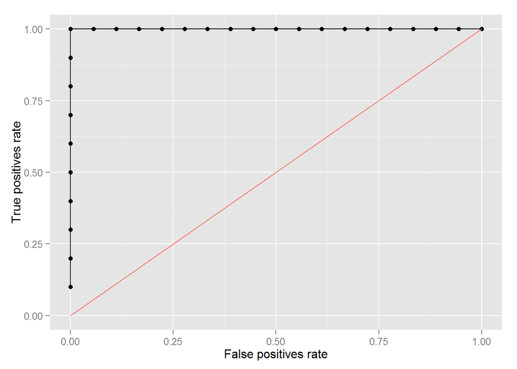

**Manhattan Plot**

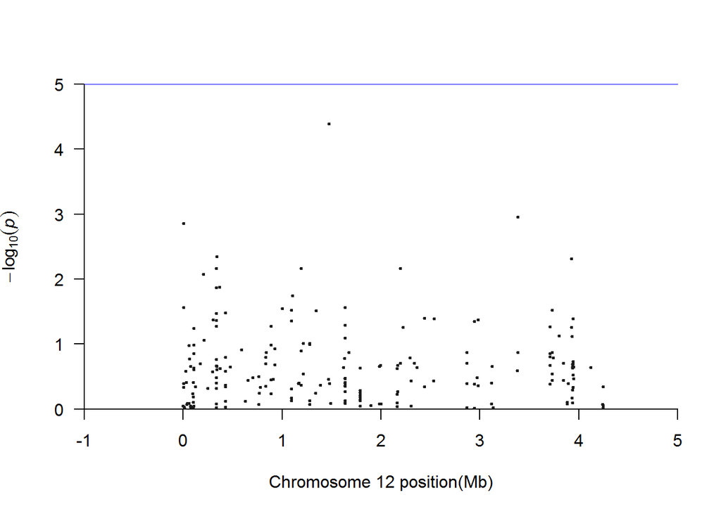

```r
manhattan(test.gwas, cex = .5)
```

**Q-Q Plot**

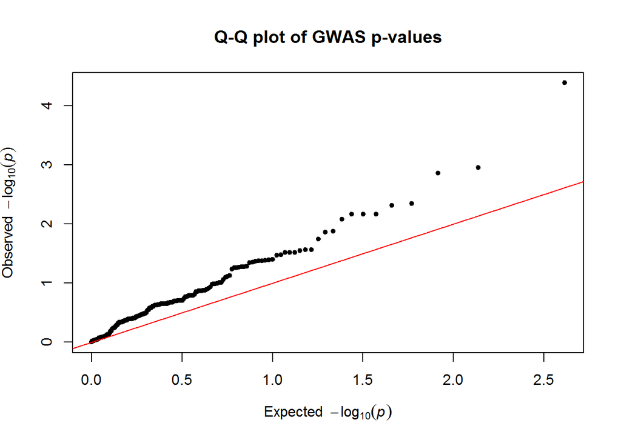

**Significant mutations**

|  | ps | allele1 | allele0 | af | p_lrt | bonferroni | holm | hochberg | fdr | BY |
| --- | --- | --- | --- | --- | --- | --- | --- | --- | --- | --- |
| 5 | 6579 | T | C | 0.036 | 0.00138012 | 0.284305 | 0.281545 | 0.281545 | 0.094768 | 0.55985 |
| 158 | 202369 | C | G | 0.071 | 0.00836071 | 1.000000 | 1.000000 | 0.991950 | 0.191367 | 1.00000 |
| 225 | 333624 | G | T | 0.357 | 0.00686410 | 1.000000 | 1.000000 | 0.991950 | 0.176751 | 1.00000 |
| 254 | 338618 | G | C | 0.464 | 0.00453151 | 0.933490 | 0.919896 | 0.919896 | 0.176751 | 1.00000 |
| 770 | 1191746 | A | G | 0.357 | 0.00686406 | 1.000000 | 1.000000 | 0.991950 | 0.176751 | 1.00000 |
| 913 | 1473252 | G | A | 0.214 | 0.00004066 | 0.008376 | 0.008376 | 0.008376 | 0.008376 | 0.04948 |
| 1368 | 2196889 | G | A | 0.357 | 0.00686410 | 1.000000 | 1.000000 | 0.991950 | 0.176751 | 1.00000 |
| 2008 | 3382124 | T | C | 0.321 | 0.00109821 | 0.226231 | 0.225133 | 0.225133 | 0.094768 | 0.55985 |
| 2353 | 3927774 | A | G | 0.143 | 0.00487918 | 1.000000 | 0.985593 | 0.985593 | 0.176751 | 1.00000 |

## ‘CAPR-nodup’ Details

**ROC learning curve**

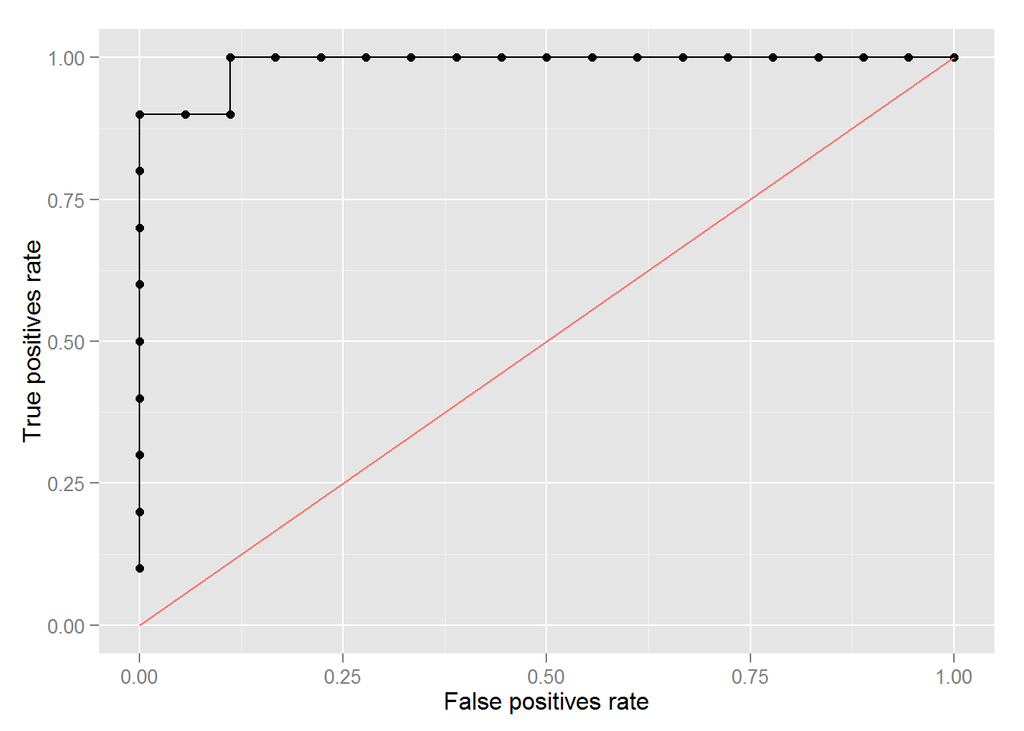

**Manhattan Plot**

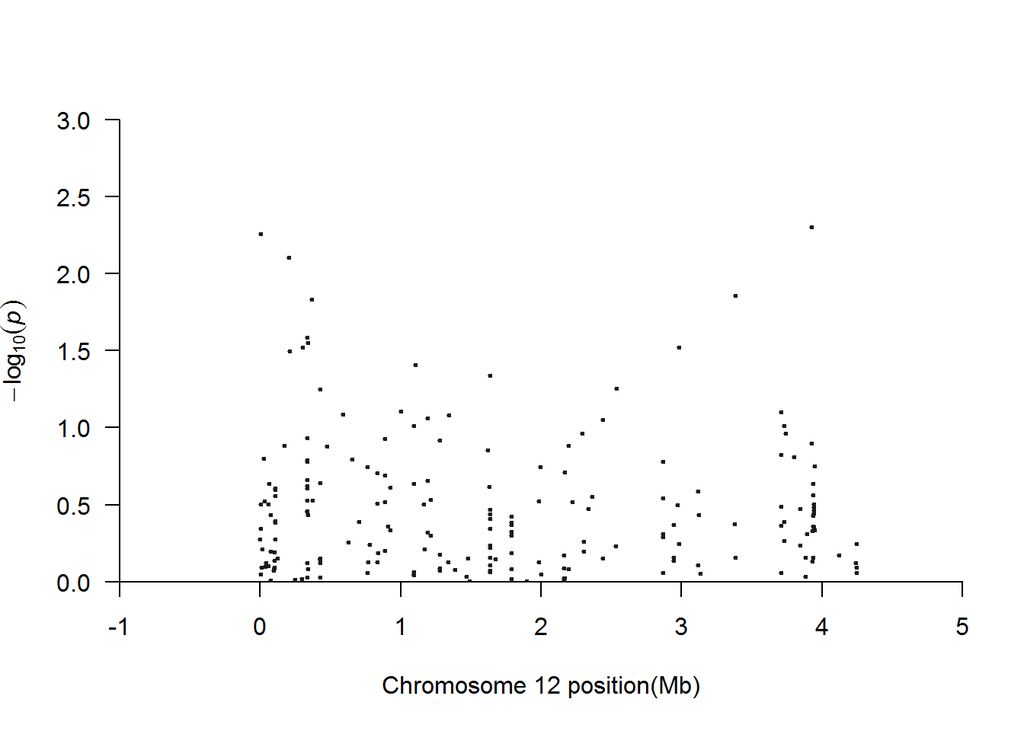

```r
manhattan(test.gwas, cex = .5)
```

**Q-Q Plot**

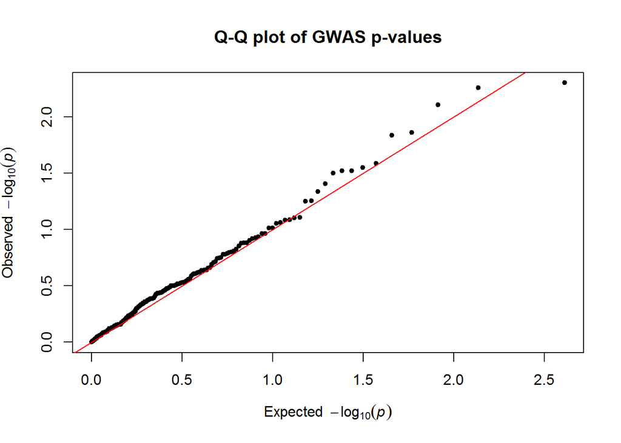

**Significant mutations**

|  | ps | allele1 | allele0 | af | p_lrt | bonferroni | holm | hochberg | fdr | BY |
| --- | --- | --- | --- | --- | --- | --- | --- | --- | --- | --- |
| 5 | 6579 | T | C | 0.036 | 0.005508 | 1 | 1 | 0.9954 | 0.5356 | 1 |
| 31 | 202369 | C | G | 0.071 | 0.007838 | 1 | 1 | 0.9954 | 0.5356 | 1 |
| 185 | 3927774 | A | G | 0.143 | 0.005004 | 1 | 1 | 0.9954 | 0.5356 | 1 |

# Dataset: ‘dataset_8-S-II_2ndLineNonInj_bin’ prediction accuracy summary

| drug | 1 | 0 | 1/1 | 1/0 | 0/1 | 0/0 | precission | recall | f1 | accuracy |
| --- | --- | --- | --- | --- | --- | --- | --- | --- | --- | --- |
| CYCL | 4 | 39 | 0.0930 | 0 | 0.6279 | 0.2791 | 0.1290 | 1 | 0.2286 | 0.3721 |
| CYCL-nodup | 4 | 39 | 0.0930 | 0 | 0.9070 | 0.0000 | 0.0930 | 1 | 0.1702 | 0.0930 |
| ETH | 1 | 47 | 0.0208 | 0 | 0.0000 | 0.9792 | 1.0000 | 1 | 1.0000 | 1.0000 |
| ETH-nodup | 1 | 47 | 0.0208 | 0 | 0.0000 | 0.9792 | 1.0000 | 1 | 1.0000 | 1.0000 |
| PARA | 4 | 44 | 0.0833 | 0 | 0.7083 | 0.2083 | 0.1053 | 1 | 0.1905 | 0.2917 |
| PARA-nodup | 4 | 44 | 0.0833 | 0 | 0.7083 | 0.2083 | 0.1053 | 1 | 0.1905 | 0.2917 |

## ‘CYCL’ Details

**ROC learning curve**

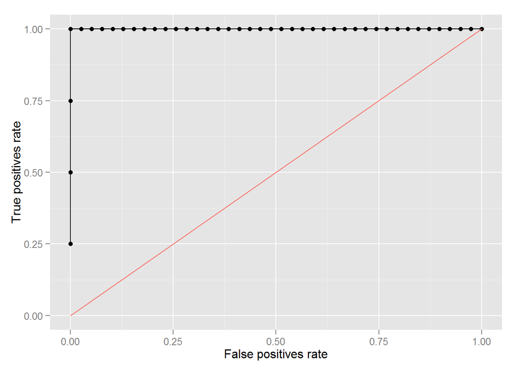

**Manhattan Plot**

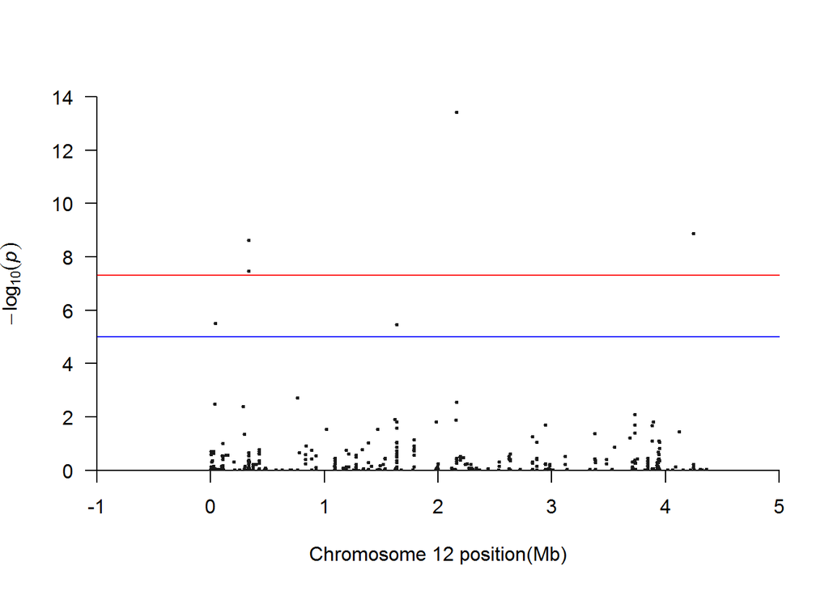

```r
manhattan(test.gwas, cex = .5)
```

**Q-Q Plot**

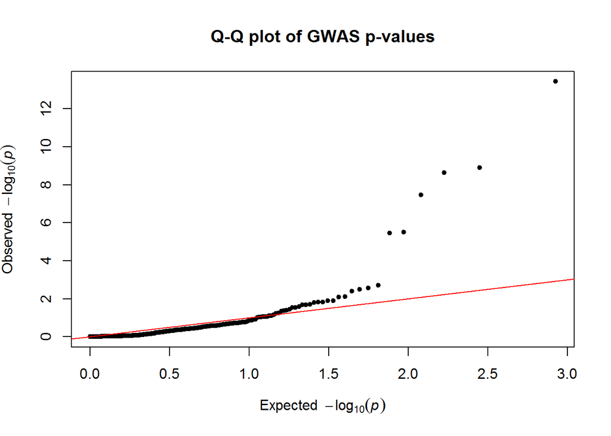

**Significant mutations**

|  | ps | allele1 | allele0 | af | p_lrt | bonferroni | holm | hochberg | fdr | BY |
| --- | --- | --- | --- | --- | --- | --- | --- | --- | --- | --- |
| 69 | 35978 | A | G | 0.070 | 0.00327580300000000 | 1.00000000000000 | 1.00000000000000 | 0.99984930000000 | 0.15359876288889 | 1.0000000000000 |
| 81 | 42227 | A | G | 0.047 | 0.00000317546200000 | 0.00134004496400 | 0.00132734311600 | 0.00132734311600 | 0.00024060702767 | 0.0015936378731 |
| 407 | 285751 | T | C | 0.116 | 0.00408276100000000 | 1.00000000000000 | 1.00000000000000 | 0.99984930000000 | 0.17229251420000 | 1.0000000000000 |
| 492 | 336344 | G | A | 0.023 | 0.00000000235263700 | 0.00000099281281 | 0.00000098810754 | 0.00000098810754 | 0.00000033093760 | 0.0000021919339 |
| 495 | 336369 | T | C | 0.047 | 0.00000003405114000 | 0.00001436958108 | 0.00001426742766 | 0.00001426742766 | 0.00000359239527 | 0.0000237938900 |
| 994 | 761158 | T | C | 0.419 | 0.00192176000000000 | 0.81098272000000 | 0.79945216000000 | 0.79945216000000 | 0.11585467428571 | 0.7673524689208 |
| 2045 | 1637662 | C | G | 0.070 | 0.00000342095300000 | 0.00144364216600 | 0.00142653740100 | 0.00142653740100 | 0.00024060702767 | 0.0015936378731 |
| 2651 | 2163353 | A | C | 0.047 | 0.00000000000003732 | 0.00000000001575 | 0.00000000001575 | 0.00000000001575 | 0.00000000001575 | 0.0000000001043 |
| 2653 | 2163357 | T | C | 0.023 | 0.00274307400000000 | 1.00000000000000 | 1.00000000000000 | 0.99984930000000 | 0.14469715350000 | 0.9583878999151 |
| 4460 | 3730787 | A | G | 0.279 | 0.00817078700000000 | 1.00000000000000 | 1.00000000000000 | 0.99984930000000 | 0.28733934283333 | 1.0000000000000 |
| 4464 | 3731632 | G | C | 0.209 | 0.00801372900000000 | 1.00000000000000 | 1.00000000000000 | 0.99984930000000 | 0.28733934283333 | 1.0000000000000 |
| 5287 | 4247607 | G | A | 0.140 | 0.00000000130203400 | 0.00000054945835 | 0.00000054815631 | 0.00000054815631 | 0.00000027472917 | 0.0000018196427 |